# ICAOD: An R Package for Finding Optimal designs for Nonlinear Statistical Models by Imperialist Competitive Algorithm

Ehsan Masoudi

Department of Psychology, University of Münster

Heinz Holling

Department of Psychology, University of Münster

Weng Kee Wong

Department of Biostatistics, UCLA Fielding School of Public Health

Seongho Kim

Biostatistics and Bioinformatics Core, Karmanos Cancer Institute

2022-12-20

Abstract

Optimal design ideas are increasingly used in different disciplines to rein in experimental costs. Given a nonlinear statistical model and a design criterion, optimal designs determine the number of experimental points to observe the responses, the design points and the number of replications at each design point. Currently, there are very few free and effective computing tools for finding different types of optimal designs for a general nonlinear model, especially when the criterion is not differentiable. We introduce an R package [*ICAOD*](https://CRAN.R-project.org/package=ICAOD) to find various types of optimal designs and they include locally, minimax and Bayesian optimal designs for different nonlinear statistical models. Our main computational tool is a novel metaheuristic algorithm called imperialist competitive algorithm (ICA) and inspired by socio-political behavior of humans and colonialism. We demonstrate its capability and effectiveness using several applications. The package also includes several theory-based tools to assess optimality of a generated design when the criterion is a convex function of the design.

# Introduction

Optimal designs have been extensively applied in many research studies to reduce the cost of experimentation. For instance, Holling and Schwabe (2013) provided examples in psychology and Dette et al. (2010) gave examples in dose-response studies. Further applications of optimal designs in engineering and epidemiology are described in Berger and Wong (2009), which also contains applications of optimal design ideas in other disciplines. Given a statistical model and an optimality criterion, optimal designs determine the optimal number of design points required, their locations to observe the responses and the number of replications required at each location. The optimality criterion should accurately reflect the objective of the study to the extent possible and is usually formulated as a scalar function of the Fisher information matrix (FIM) that measures the worth of the design (Lehmann and Casella 1998). For example, if the objective of a study is to estimate the model parameters as accurately as possible, $D$-optimality is often used. Such an optimal design maximizes the determinant of the FIM and is called $D$-optimal. When errors are independent and normally distributed, $D$-optimal designs minimize the volume of the confidence ellipsoid of the model parameters by minimizing the generalized variance, i.e., the determinant of the variance-covariance matrix (Abdelbasit and Plackett 1983).

For nonlinear models, the FIM depends on the unknown model parameters to be estimated and so the design criterion cannot be directly optimized. There are different approaches to deal with this parameter dependency: a) *locally optimal designs:* These are found by replacing the unknown parameters with some estimates obtained from a pilot or previous study (Chernoff 1953). Locally optimal designs usually become inefficient when the replaced estimates are far from their true unknown values. b) *minimax optimal designs:* They minimize the maximum inefficiency over a user-selected parameter space (Sitter 1992). The optimal designs are conservative in that they protect the experiment from the worst case scenario that may happen from a poor choice of parameter values over a user-specified space of plausible values for the unknown parameters. Finding minimax optimal designs is complicated because it involves solving multi-level nested optimization problems and the objective function (minimax criterion) is not differentiable. c) *Bayesian optimal designs:* These optimal designs are found by optimizing an optimality criterion averaged over a user-specified (continuous) prior distribution for the unknown parameters (Chaloner and Larntz 1989; Chaloner and Verdinelli 1995; Atkinson 1996). Strictly speaking, the latter are not fully Bayesian because they do not involve computing a posterior distribution. Instead, they borrow the concept of having prior distributions to find robust designs for the frequentists (Graßhoff, Holling, and Schwabe 2012; Bürkner, Schwabe, and Holling 2019). Accordingly, they are sometimes referred to as “pseudo” Bayesian designs (Firth and Hinde 1997). In the optimal design literature, Bayesian optimal designs found under a discrete prior distribution are usually referred to as *robust* or *optimum-on-average* designs (Valerii V. Fedorov and Hackl 2012). For an overview of optimal designs for nonlinear models, see Valerii V. Fedorov and Leonov (2013).

There are several software packages to create and analyze design of experiment (DoE) for different purposes. For a review on statistical R packages in design of experiments, see https://cran.r-project.org/web/views/ExperimentalDesign.html. Only a few of them are able to find different types of optimal designs to deal with the parameter dependency for various nonlinear models. To the best of our knowledge, none of the available software packages, commercial or otherwise, provides an option to find minimax optimal designs for nonlinear models. For example, the R package [*LDOD*](https://CRAN.R-project.org/package=LDOD) (Masoudi, Sarmad, and Talebi 2013) finds locally $D-$optimal *approximate* designs for a large class of nonlinear models and the [*acebayes*](https://CRAN.R-project.org/package=acebayes) R package (A. Overstall, Woods, and Adamou 2017) determines a more general class of fully Bayesian *exact* designs using the approximate coordinate exchange algorithm (A. M. Overstall and Woods 2017). Likewise, the recently available [*VNM*](https://CRAN.R-project.org/package=VNM) R package finds multiple-objective locally optimal designs for a specific model, i.e., the four-parameter Hill model commonly used in dose-response studies (Hyun, Wong, and Yang 2018). Among the commercial software, JMP (SAS Institute Inc. 2016) can also find Bayesian $D-$optimal exact designs for nonlinear models.

This paper introduces the R package [*ICAOD*](https://CRAN.R-project.org/package=ICAOD) (Masoudi et al. 2020) for finding a variety of optimal designs for nonlinear models using a novel metaheuristic algorithm called *imperialist competitive algorithm(ICA)*. This algorithm is inspired by socio-political behavior of humans (Atashpaz-Gargari and Lucas 2007; Hosseini and Al Khaled 2014) and is modified by Masoudi, Holling, and Wong (2017) and Masoudi et al. (2019) to find optimal designs for nonlinear models. We believe that this [*ICAOD*](https://CRAN.R-project.org/package=ICAOD) package is the first single self-contained statistical package that presents a framework to find locally, minimax and Bayesian optimal designs for nonlinear models. Similar to many popular nature-inspired metaheuristic algorithms, such as particle swarm optimization (PSO) algorithm (Kennedy and Eberhart 1995), ICA does not have a rigorous proof of convergence (Yang 2011). When the criterion is a convex function on the set of design measures, equivalence theorems are available and the [*ICAOD*](https://CRAN.R-project.org/package=ICAOD) package includes tools to confirm optimality of a design. More generally, the proximity of any design to the optimum without knowing the latter can be evaluated in terms of an efficiency lower bound. In particular, if this bound is unity, this confirms optimality of the design. This feature is useful to recognize a case of pre-mature convergence in optimal design problems.

The next section reviews the statistical setup and theory for finding optimal designs for nonlinear models. The fourth section describes the imperialist competitive algorithm (ICA) and the fifth section provides implementation details for the [*ICAOD*](https://CRAN.R-project.org/package=ICAOD) package. In the sixth section, we provide two examples to show the functionality of the [*ICAOD*](https://CRAN.R-project.org/package=ICAOD) package. The seventh section finds locally and minimax $D-$optimal designs for a logistic model with application in educational testing and The eighth section presents optimum-on-average and Bayesian $D-$optimal designs for a sigmoid Emax model for dose-response studies. The [*ICAOD*](https://CRAN.R-project.org/package=ICAOD) package was first written to find locally $D-$optimal designs, but it now also finds user-defined optimal designs. The ninth section illustrates how to use this feature to find $c-$optimal designs for a two-parameter logistic model in dose response studies. The last section concludes with a summary.

# Background and optimal designs

Let $E(Y)=f(\boldsymbol{x},\boldsymbol{\theta})$ be the mean of the response $Y$ at the values of the independent variables $\boldsymbol{x}$ defined on a user-selected *design space* $\chi$, and let $f$ be a known function, apart from the model parameters $\boldsymbol{\theta}= (\theta_1,..., \theta_p)^T$. Throughout we assume that there are resources to take $N$ observations for the study and given an optimality criterion, we want to find the best choices for the levels of the independent variables to observe the outcome $Y$. There are two types of designs: exact and approximate.An *exact* design $\xi_N$ on $\chi$ is defined by a set of $k$ distinct levels $\boldsymbol{x}_i$,
$$\label{eq-exact-design}
\xi_N =
\left\{
\begin{array}{cccc}
\boldsymbol{x}_1 & \boldsymbol{x}_2 & ... &
\boldsymbol{x}_k\\
n_1/N & n_2/N & ...& n_k/N
\end{array}
\right\}, (\#eq:eq-exact-design)$$
where $\boldsymbol{x}_j \in \chi$, $n_j$ is the number of replications of $\boldsymbol{x}_j$ in the observations sample and $N = \sum_{j=1}^kn_j$. Here, $x_j, j = 1..., k$ are referred to as *support points* or *design points* of $\xi_N$. Given $N$ and a specific design criterion, an optimal exact design finds the best value of $k$ and the best values of $x_1,\ldots,x_k,n_1,\ldots,n_k$. Such optimization problems are notoriously difficult and in practice, we find optimal approximate designs instead. They are probability measure on $\chi$ are found independent of the sample size $N$. An approximate design $\xi$ with $k$ support points has the form
$$\label{eq-approximate-design}
\xi =
\left\{
\begin{array}{cccc}
\boldsymbol{x}_1 & \boldsymbol{x}_2 & ... &
\boldsymbol{x}_k\\
w_1 & w_2 & ...& w_k
\end{array}
\right\}, (\#eq:eq-approximate-design)$$
where $w_j> 0$ is the proportion of observations that is assigned to $\boldsymbol{x}_j$ and $\sum_{j=1}^{k} w_j = 1$. It is implemented by first rounding each value of $Nw_i$ to the nearest integer $Nw_i^*$ subject to $Nw_1^*+\ldots+Nw_k^*=N$ and taking $Nw_i*$ observations at $\boldsymbol{x}_i,i=1,\ldots,k$. Some optimal rounding procedures are available in Pukelsheim and Rieder (1992). When the design criterion is formulated as a convex function of the FIM, there are algorithms for finding many types of optimal approximate designs and theory to confirm optimality of an approximate design. When the design is not optimal, a theory-based efficiency lower bound of the design is available to determine its proximity to the optimum, without knowing the optimum. For these reasons, we focus on optimal approximate designs found under a convex functional in the rest of the paper.

To find an approximate design that minimizes a convex design criterion $\psi$ over the space of all designs on $\chi$. We have to determine the optimal number of support points, $k$, the optimal support points $\boldsymbol{x}_1,\ldots,\boldsymbol{x}_k$ and their corresponding $w_1,\ldots,w_k$. For example, if estimating model parameters is of interest, $D-$optimality, defined by the logarithm of the determinant of the inverse of the FIM, is a convex functional over the space of all designs on $\chi$ (Valerii V. Fedorov and Leonov 2013; Silvey 1980) and the design that minimuzes it is called $D-$optimal. In what follows, we focus on the $D-$optimality criterion and briefly discuss other optimality criteria and optimal designs which can be studied similarly.

Assuming all observation errors are independent and normally distributed with means $0$ and a constant variance $\texttt{(}Y)$, the FIM of a generic $k$-point approximate design $\xi$ is given by
$$\label{eq:FIM}
M(\xi,\boldsymbol{\theta}) = \sum_{i=1}^k w_i
I(\boldsymbol{x}_i,\boldsymbol{\theta}), (\#eq:FIM)$$
where
$$I(\boldsymbol{x}_i,\boldsymbol{\theta}) =
\frac{1}{\texttt{(}Y_i)}\nabla
f(\boldsymbol{x}_i,\boldsymbol{\theta})\nabla
f(\boldsymbol{x}_i,\boldsymbol{\theta})^T,$$
and $\nabla f(\boldsymbol{x}_i,\boldsymbol{\theta})^T=\left( \frac{\partial f(\boldsymbol{x}_i,\boldsymbol{\theta})}{\partial \theta_1}, \cdots,\frac{\partial f(\boldsymbol{x}_i,\boldsymbol{\theta})}{\partial \theta_p} \right)$. Here, $\frac{\partial f(\boldsymbol{x}_i,\boldsymbol{\theta})}{\partial \theta_j}$ denotes the partial derivative of $f$ with respect to $\theta_j$. The FIM is singular if $k < p$. To avoid singular designs, i.e., designs with singular Fisher information matrices, we assume $k\geq p$.

Clearly, the FIM @ref(eq:FIM) depends on the unknown parameters for nonlinear models. Different approaches have been proposed to deal with this parameter dependency based on the type of information available for the unknown parameters. For example, let $\boldsymbol{\theta}_0$ be an initial guess for $\boldsymbol{\theta}$ available from a similar study. A locally $D-$optimal design $\xi^*_{loc}$ minimizes
$$\label{eq:locally-criterion}
\psi_{loc}(\xi) = -\log|M(\xi,
\boldsymbol{\theta}_0)|, (\#eq:locally-criterion)$$
where $|\cdot|$ denotes the determinant. In practice, it is more realistic to assume that the unknown parameters belong to a user-specified parameter space $\Theta$, which is comprised of all possible values for $\boldsymbol{\theta}$. Given $\Theta$, we can find minimax optimal designs that minimize the maximum inefficiency over $\Theta$ and protect the experiment from the worst-case scenario over the parameter space. A minimax $D-$optimal design $\xi^*_{min}$ is obtained by minimizing
$$\label{eq:minimax-criterion}
\psi_{min}(\xi) = \max_{\boldsymbol{\theta}\in \Theta} -\log|M(\xi,
\boldsymbol{\theta})|, (\#eq:minimax-criterion)$$
over the space of all designs on $\chi$. The minimax problem @ref(eq:minimax-criterion) is a bi-level nested optimization problem with inner and outer optimization problems. Given any arbitrary design, the inner optimization problem is to maximize the $D-$criterion $-\log|M(\xi, \boldsymbol{\theta})|$ over $\Theta$ to find the maximum inefficiency and the outer optimization problem is to minimize the maximum of the inner problem over the space of all designs on $\chi$. Alternatively, when a prior distribution $\pi_{\Theta}(\boldsymbol{\theta})$ is available for the unknown parameters on $\Theta$, Bayesian optimal designs may also be found: a (pseudo) Bayesian $D-$optimal design $\xi_{bayes}^*$ minimizes
$$\label{eq:bayesian-criterion}
\psi_{bayes}(\xi) = \int_{\boldsymbol{\theta}\in \Theta} -\log|M(\xi,
\boldsymbol{\theta})| \pi_{\Theta}(\boldsymbol{\theta})
d\boldsymbol{\theta}. (\#eq:bayesian-criterion)$$
When $\pi_{\Theta}(\boldsymbol{\theta})$ is a discrete prior, the obtained designs are sometimes referred to as *optimum-on-average* or *robust* designs.

One advantage of working with approximate designs is existence of an equivalence theorem, which can be used to verify the optimality of a given design if the criterion is a convex function on the set of design measures. Each convex optimality criterion gives rise to a different equivalence theorem, but they generally have the same form. For example, a design $\xi_{loc}^*$ is locally $D-$optimal if and only if the following inequality holds for all $\boldsymbol{x}\in \chi$,
$$\label{eq:sensitivity-locally}
c_{loc}(\boldsymbol{x}, \xi_{loc}^*) =
\mathop{\mathrm{tr}}M^{-1}(\xi_{loc}^*,
\boldsymbol{\theta}_{0})I(\boldsymbol{x}, \boldsymbol{\theta}_{0}) - p
\leq 0, (\#eq:sensitivity-locally)$$
with equality in @ref(eq:sensitivity-locally) at all support points of $\xi_{loc}^*$. The left hand-side of inequality @ref(eq:sensitivity-locally) is sometimes called *sensitivity function*. The equivalence theorem for Bayesian $D-$optimality criterion is very similar (Kiefer and Wolfowitz 1959; Chaloner and Larntz 1989): a design $\xi_{bayes}^*$ is a Bayesian $D-$optimal design if and only if the following inequality holds for all $\boldsymbol{x}\in \chi$,
$$\label{eq:sensitivity-bayesian}
c_{bayes}(\boldsymbol{x}, \xi_{bayes}^*) = \int_{\Theta} tr \{
M^{-1}(\xi_{bayes}^*, \boldsymbol{\theta})I(\boldsymbol{x},
\boldsymbol{\theta})\}\pi(\boldsymbol{\theta}) d\theta-p \leq
0, (\#eq:sensitivity-bayesian)$$
with equality in @ref(eq:sensitivity-bayesian) at all support points of $\xi_{bayes}^*$. However, the equivalence theorem for a minimax type criterion takes on a more complicated form because @ref(eq:minimax-criterion) is not differentiable. The equivalence theorem states that a design $\xi^*_{min}$ is minimax $D-$optimal among all the designs on $\chi$ if and only if there exists a probability measure $\mu^*$ on
$$\label{eq:A-set}
A(\xi_{min}^*) = \left\{\boldsymbol{\nu}\in \Theta \mid
-\log|M(\xi_{min}^*, \boldsymbol{\nu})| = \max_{\boldsymbol{\theta}\in
\Theta} -\log|M(\xi_{min}^*, \boldsymbol{\theta})|
\right\}, (\#eq:A-set)$$
such that the following inequality holds for all $\boldsymbol{x}\in \chi$,
$$\label{eq:sensitivity-minimax}
c_{min}(\boldsymbol{x}, \xi_{min}^*) = \int_{A(\xi_{min}^*)}
\mathop{\mathrm{tr}}M^{-1}(\xi_{min}^*, \boldsymbol{\nu})
I(\boldsymbol{x}, \boldsymbol{\nu})\mu^* d(\boldsymbol{\nu})-p \leq
0, (\#eq:sensitivity-minimax)$$
with equality in @ref(eq:sensitivity-minimax) at all support points of $\xi_{min}^*$ (Wong 1992; V. V. Fedorov 1980; King and Wong 2000; Berger, King, and Wong 2000). The set $A(\xi_{min}^*)$ is sometimes called the *answering set* of $\xi^*$ and the measure $\mu^*$ is a sub-gradient of the non-differentiable criterion evaluated at $M(\xi_{min}^*,\nu)$. Understanding the properties of the sub-gradients and how to find them efficiently for the minimax optimal design problems present a key problem in solving this type of problems. In particular, there is no theoretical rule on how to choose the number of points in $A(\xi_{min}^*)$ as support for the measure $\mu^*$ and they would have to be found by trial-and-error. For more details, see Masoudi, Holling, and Wong (2017). When $\chi$ is one or two dimensional, it is very common to plot the sensitivity function versus $\boldsymbol{x}\in \chi$ and visually inspect whether the graph meets the conditions in the equivalence theorem. If it does, the generated design is optimal; otherwise it is not optimal.

We measure the efficiency of one design $\xi_1$ relative to another design $\xi_2$ using their criterion values. For example, for $D-$optimality @ref(eq:locally-criterion), we use
$$\label{eq:locally-D-efficiency}
eff_{loc} =\left(\frac{|M(\xi_1, \boldsymbol{\theta})|}{|M(\xi_2,
\boldsymbol{\theta})|}\right)^{1/p} =\exp\left(\frac{\psi_{loc}(\xi_2) -
\psi_{loc}(\xi_1) }{p}\right). (\#eq:locally-D-efficiency)$$
The relative $D-$efficiency @ref(eq:locally-D-efficiency) may be interpreted in term of sample size; if its value is $\rho$, then $\xi_1$ requires $1/\rho$ times as many observations to have the same $D-$efficiency as $\xi_2$. This means that, when $\xi_2$ is an optimal design, about $(1/\rho-1)100\%$ more number of observations are required for design $\xi_1$ to do as well as the optimal design. Similarly, we define Bayesian and minimax $D-$efficiencies by replacing $\psi_{loc}$ with $\psi_{min}$ and $\psi_{bayes}$, respectively. Standardly, @ref(eq:locally-D-efficiency) becomes the $D-$efficiency of $\xi_1$ when $\xi_2$ is the $D-$optimal design.

When the design criterion is a convex functional, we can use the equivalence theorem to quantify the proximity of a design $\xi$ to the optimal design without knowing the latter by means of the efficiency lower bound (ELB). For example, for $D-$optimality, we have
$$\label{eq:ELB}
ELB = \frac{p}{p + \max_{\boldsymbol{x}\in \chi}c(\boldsymbol{x},
\xi)}, (\#eq:ELB)$$
where $c(\boldsymbol{x}, \xi)$ is the sensitivity function associated with $D-$optimality. The value of the ratio in @ref(eq:ELB) is between $0$ and $1$, and it is equal to $1$ if and only if the design is optimal. The efficiency bounds are not unique and can be varously derived using somewhat similar arguments, for example, see Atwood (1969) and Pázman (1986).

# Imperialist competitive algorithm for finding optimal designs

The imperialist competitive algorithm (ICA) is an evolutionary algorithm inspired from colonialism and socio-political behavior of humans, where developed countries attempt to take over or colonize less-developed countries to use their resources and extend their power (Atashpaz-Gargari and Lucas 2007). Within the optimization framework, ICA has a population of solutions called *countries*. In optimal design problems, each country is the location of the support points and the corresponding weights of a design on the space of all possible designs. ICA divides the population of countries into some sub-populations called *empires*. Each empire contains one *imperialist* and some *colonies*. The imperialist is the most powerful country within the empire. Here, the power of a country is defined to be a function of its cost value, i.e., criterion value. This means that, in a minimization problem, countries with smaller cost values are stronger. In ICA, there are two types of evolutionary moves: a) evolution within each empire, and, b) evolution among the empires. In the earlier, the colonies within each empire start to move or be absorbed toward their relevant imperialist country in a process called *assimilation* (Lin, Cho, and Chuan 2013). During this process, a colony may reach a better position than its imperialist. In this case, the imperialist loses its rank and the colony becomes the new imperialist. The assimilation improves searching around the better current solutions and so enhances the exploitation of the algorithm.

The evolution among the empires is achieved by a process called *imperialists competition*. In this process, the most powerful empires receive more chances to take possession of the colonies of the weakest empires. The competition step in ICA improves the exploration of the algorithm in a search for the global optimum. When an empire does not have any colony, it will be eliminated. ICA continues until it satisfies the stopping rule conditions. For more details, see Atashpaz-Gargari and Lucas (2007) and Hosseini and Al Khaled (2014).

To apply ICA for an optimal design problem, the user should first provide an initial guess about the number of support point $k (\geq p)$. In practice, the user can start by $p$ and increment its value by one until the equivalence theorem confirms the optimality of the current best design, which is the country with the least cost value. In optimal design problems, the ELB defined by @ref(eq:ELB) can be used to build a stopping rule condition for ICA. For example, the algorithm can be stopped when the value of the ELB of the best current design is larger than, say, $0.95$. Clearly, finding ELB in each iteration increases the CPU time required by the algorithm as another optimization problem has to be solved to find maximum of the sensitivity function over $\chi$. This is especially true for minimax and Bayesian type criteria, because the sensitivity function for the earlier involves solving a bi-level nested optimization problem and the latter requires approximating integrals. Therefore, we prefer to calculate the ELB periodically, say, after every $100$ iterations, instead of every iteration to save the CPU time.

# Implementation of optimal design problems in ICAOD

Different functions are available to find optimal designs for nonlinear models in [*ICAOD*](https://CRAN.R-project.org/package=ICAOD): a) `locally()`: Finds locally optimal designs, b) `minimax()`: Finds minimax optimal designs , c) `bayes()`: Finds Bayesian optimal designs and d) `robust()`: Finds optimum-on-average or robust designs. Throughout this paper, we refer to them as “OD functions”. [*ICAOD*](https://CRAN.R-project.org/package=ICAOD) uses the S3 object oriented system and works with an object of class ‘`minimax`’. The class ‘`minimax`’ has its own `plot`, `print` and `update` method. The `plot` method is used to plot the sensitivity function and also calculate the ELB for the output design. The `print` method is to display the brief profile of ICA iterations and the summary of identified optimal designs. The `update` method is for executing the algorithm for more number of iterations. By default, OD functions are defined to determine $D-$optimal designs. In the section `User-Specified Optimality Criteria`, we demonstrate how to specify user-defined optimality criteria. In what follows, the OD functions are explained in detail.

## Locally optimal designs

The `locally()` function finds locally optimal designs and its main arguments are:

```r
locally(formula, predvars, parvars, family = gaussian(), fimfunc = NULL,
        lx, ux, k, iter, ICA.control = list(), sens.control = list(),
        crt_func = NULL, sens_func = NULL,
        inipars)
```

The arguments in the first three lines of codes are common between the OD functions. Table 1 provides an overview of them.

Table 1: Overview of the most important common arguments of the OD functions.

[output not shown]

The arguments in the first line are required to construct the FIM of the model; `inipars` is equivalent to $\boldsymbol{\theta}_0$ in @ref(eq:locally-criterion) and defines the vector of initial estimates for the model parameters.

The [*ICAOD*](https://CRAN.R-project.org/package=ICAOD) package includes a formula interface to specify the model of interest. For example, assume the two-parameter logistic model defined by
$$\label{eq:logistic-formula}
f(x, \boldsymbol{\theta}) = \frac{1}{1 +
\exp(-b(x-a))}, (\#eq:logistic-formula)$$
where $\boldsymbol{\theta}= (a, b)$ is the vector of model parameters and $x$ is the model predictor. To define @ref(eq:logistic-formula) in [*ICAOD*](https://CRAN.R-project.org/package=ICAOD), we can set `formula = 1/(1 + exp(-b * (x-a)))`, `predvars = "x"`, `parvars = c("a", "b")` and `family = "binomial"` (or `family = binomial()`). Alternatively, one may pass the FIM of @ref(eq:logistic-formula) as an R `function` via the argument `fimfunc` directly. In this option, the arguments of the defined function must be a) `x`: is a `vector` of $(\boldsymbol{x}_1, ..., \boldsymbol{x}_k)$ in @ref(eq:eq-approximate-design), b) `w`: is a `vector` of $(w_1, ..., w_k)$ in @ref(eq:eq-approximate-design), and c) `param`: is a `vector` of $\boldsymbol{\theta}$ in @ref(eq:logistic-formula). The output is the FIM of @ref(eq:logistic-formula) evaluated at the given `x`, `w` and `param` as a `matrix`.

The argument `sens.control` is a list of control parameters for `nloptr()` available in the [*nloptr*](https://CRAN.R-project.org/package=nloptr) package (Johnson 2014). This function is used here to solve $\max_{\boldsymbol{x}\in \chi}c(\boldsymbol{x}, \xi)$ for computing the ELB @ref(eq:ELB). When not given, it will be created automatically by the function `sens.control`. We recommend not to change its default values as they have been successfully tested for a large number of problems.

The `crt_func` and `sens_func` arguments are used to find a user-defined optimal designs, which are described in the section `User-Specified Optimality Criteria`.

## Minimax optimal designs

The `minimax()` function finds minimax optimal designs and its main arguments are:

```r
minimax(formula, predvars, parvars, family = gaussian(), fimfunc = NULL,
        lx, ux, k, iter, ICA.control = list(), sens.control = list(),
        crt_func = NULL, sens_func = NULL,
        lp, up, n.grid = 0,
        sens.minimax.control = list(), crt.minimax.control = list())
```

The first three lines of codes are similar to the ones in `locally()` and the rest of the arguments are used to evaluate the minimax criterion @ref(eq:minimax-criterion) and its sensitivity function @ref(eq:sensitivity-minimax) at a given design. Table 2 presents an overview of the arguments specifically available in `minimax()`.

In [*ICAOD*](https://CRAN.R-project.org/package=ICAOD), the parameter space $\Theta$ are either continuous or discrete. Note that the lower bound and upper bound of $\Theta$ are specified via the arguments `lp` and `up`, respectively. When $\Theta$ is continuous, [*ICAOD*](https://CRAN.R-project.org/package=ICAOD) uses `nloptr()` to solve the inner maximization problem in @ref(eq:minimax-criterion) over $\Theta$ at a given design. The default optimization algorithm from `nloptr()` is the DIRECT-L algorithm, which is a deterministic search algorithm based on the systematic division of the search domain into smaller and smaller hyperrectangles (Gablonsky and Kelley 2001). For our applications, the most influential tuning parameter of `nloptr()` is the maximum number of function evaluations denoted by `maxeval` (its default value is $1000$) via the `crt.minimax.control` argument. The parameter space may also be discretized. In this option, the total number of grid points is equal to `n.grid^p`. When specified, ICA evaluates the criterion at these grid points to solve the maximization problem over $\Theta$.

Table 2: Overview of the arguments that are used to evaluate minimax, Bayesian and robust (optimum-on-average) optimality criteria at a given design.

[output not shown]

## Bayesian optimal designs

The `bayes()` function finds Bayesian optimal designs and its main arguments are:

```r
bayes(formula, predvars, parvars, family = gaussian(), fimfunc = NULL,
      lx, ux, k, iter, ICA.control = list(), sens.control = list(),
      crt_func = NULL, sens_func = NULL,
      prior, crt.bayes.control = list(), sens.bayes.control = list())
```

The first three lines of codes are similar to the ones in `locally()` and the rest of the arguments are used to approximate the integrals in @ref(eq:bayesian-criterion) and @ref(eq:sensitivity-bayesian) at a given design. Table 2 presents an overview of the arguments specifically available in `bayes()`.

By default, [*ICAOD*](https://CRAN.R-project.org/package=ICAOD) uses the `hcubature()` function from the [*cubature*](https://CRAN.R-project.org/package=cubature) package (Johnson 2013; Narasimhan and Johnson 2017) to approximate the integrals. Th function `hcubature()` includes an adaptive multidimensional integration method over hypercubes known as hcubature algorithm (Berntsen, Espelid, and Genz 1991; Genz and Malik 1980). For our applications, the most important tuning parameters of the hcubature algorithm are the maximum number of integrand evaluations `maxEval` (its default value is `50000`) and a user-specified tolerance `tol` (its default value is `1e-5`). This algorithm stops either when the integral error estimate is less than the integral estimate multiplied by its value or when the it reaches the specified maximum number of function evaluations `maxEval`, whichever happens earlier. When the prior distribution is less diffuse, it is sometimes more efficient to reduce the value of `maxEval` to increase the speed of the hcubature algorithm. The control parameters of the `hcubature()` function can be regulated via the argument `crt.bayes.control`.

Alternatively, [*ICAOD*](https://CRAN.R-project.org/package=ICAOD) also offers the Gauss-Legendre and the Gauss-Hermite formulas to approximate the integrals. These methods are implemented in ICA using the [*mvQuad*](https://CRAN.R-project.org/package=mvQuad) package (Weiser 2016) and can be requested via the argument `crt.bayes.control`. For more details, see `?mvQuad::createNIGrid()`.

## Robust or optimum-on-average designs

The `robust()` function finds optimum-on-average or robust designs and its main arguments are:

```r
robust(formula, predvars, parvars, family = gaussian(), fimfunc = NULL,
       lx, ux, k, iter, ICA.control = list(), sens.control = list(),
       crt_func = NULL, sens_func = NULL,
       prob, parset)
```

The first three lines of codes are similar to the ones in `locally()` and the rest of the arguments are used to evaluate the optimum-on-average criterion at a given design. Table 2 presents an overview of the arguments specifically available in `robust()`.

# Examples

In this section, we provide two examples to show the functionality of the [*ICAOD*](https://CRAN.R-project.org/package=ICAOD) package to determine optimal designs. In the first example, we find locally and minimax $D-$optimal designs for a logistic model with applications in educational testing. In the second example, we specify Bayesian and robust optimal designs for the sigmoid Emax model with applications in dose-response studies.

## Logistic model with a single predictor

The logistic model is very popular for modeling binary outcomes. For example, consider an educational research that studies the effect of hours of practice on the mastery of a mathematical task. Let $Y$ be a binary response variable that takes the value $1$ if a subject has mastered the task and $0$ otherwise. The logistic model is defined by
$$\label{eq:logistic-single}
f(x, \boldsymbol{\theta}) = P(Y=1) = \frac{\exp(\beta_0 + \beta_1 x)}{1
+ \exp(\beta_0 + \beta_1 x)}, (\#eq:logistic-single)$$
where $x$ is the hours of practice and $\boldsymbol{\theta}= (\beta_0, \beta_1)^T$. Assume that for each subject up to six hours of practice are possible, i.e., $x \in \chi = [0, 6]$. If the purpose of the study is to estimate the model parameters accurately, an appropriate criterion is the $D-$optimality. The design questions here are a) what is the best number of levels of $x$ to apply in the study, b) what are these levels and c) how many subjects should be assigned to each level? For example, a researcher may choose a uniform design that includes an equal number of subjects who have practiced for $0, 1, 2, 3, 4, 5, 6$ hours. We denote this design by
$$\label{eq-uniform-design}
\xi_{uni} =
\left\{
\begin{array}{ccccccc}
0 & 1 & 2 & 3 & 4 & 5 & 6 \\
1/7& 1/7 & 1/7& 1/7 & 1/7 & 1/7 & 1/7
\end{array}
\right\}. (\#eq:eq-uniform-design)$$
The FIM of model @ref(eq:logistic-single) depends on the unknown parameters through $\frac{\partial f(\boldsymbol{x},\boldsymbol{\theta})}{\partial \beta_j}, j = 0, 1$. Following Berger and Wong (2005), let $\boldsymbol{\theta}_0 = (-4, 1.3333)^T$ be the best initial guess for $\boldsymbol{\theta}$ available from, say, a similar study. In [*ICAOD*](https://CRAN.R-project.org/package=ICAOD), the locally $D-$optimal design is found by

```r
R> library("ICAOD")
R> log1 <- locally(formula = ~exp(b0 + b1 * x)/(1 + exp(b0 + b1 * x)),
+                 predvars = "x", parvars = c("b0", "b1"),
+                 family = "binomial", lx = 0, ux = 6, iter = 40, k = 2,
+                 inipars = c(-4, 1.3333), ICA.control = list(rseed = 1))
R> print(log1)
Finding  locally optimal designs

Call:
  ~exp(b0 + b1 * x)/(1 + exp(b0 + b1 * x))

iter       x1       x2        w1        w2 min_cost mean_cost
1     1 1.897630 4.289279 0.4480275 0.5519725 3.585707  3.629564
5     5 1.735791 4.135709 0.4818501 0.5181499 3.574277  3.608956
9     9 1.812077 4.132323 0.4965689 0.5034311 3.569134  3.569134
14   14 1.831070 4.143704 0.4982596 0.5017404 3.568777  3.568777
18   18 1.845842 4.158716 0.4996087 0.5003913 3.568684  3.568684
22   22 1.842875 4.159136 0.4999992 0.5000008 3.568680  3.568680
27   27 1.842477 4.157866 0.4999457 0.5000543 3.568679  3.568679
31   31 1.842450 4.157647 0.4999709 0.5000291 3.568679  3.568679
35   35 1.842456 4.157634 0.4999973 0.5000027 3.568679  3.568679
40   40 1.842479 4.157646 0.4999987 0.5000013 3.568679  3.568679

Optimal designs (k=2):
  Points1 Points2
1.84248 4.15765
Weights1 Weights2
0.500   0.500

ICA iteration: 40
Criterion value:  3.568679
Total number of function evaluations: 1768
Total number of successful local search moves: 76
Total number of successful revolution moves: 48
Convergence: Maximum_Iteration
Total number of successful assimilation moves: 701
CPU time: 1.09  seconds!
```

Throughout this paper, the `rseed` argument is used to guarantee the reproducibility of the results. The algorithm stopped at iteration number $40$ because it reached the maximum number of iterations (`iter = 40`). Here, the design provided by the output assigns equal weights to $x_1 = 1.84249$ and $4.15765$. This mean that, half of the subjects should be assigned to practice nearly less than 2 hours and the other half should practice a little bit more than 4 hours. The $D-$criterion @ref(eq:locally-criterion) evaluated at this design is equal to $3.5686$. Alternatively, the optimal design at the final iteration and the detailed profiles of ICA optimization at each iteration can be obtained by

```r
R> log1$design
iter       x1       x2        w1        w2 min_cost mean_cost max_sens elb
1   40 1.842479 4.157646 0.4999987 0.5000013 3.568679  3.568679       NA  NA
time_sec
1       NA
R> log1$out
iter       x1       x2        w1        w2 min_cost mean_cost
1     1 1.897630 4.289279 0.4480275 0.5519725 3.585707  3.629564
2     2 1.894919 4.287451 0.4875810 0.5124190 3.575292  3.619014
3     3 1.895518 4.285989 0.4875810 0.5124190 3.575159  3.616086
4     4 1.735791 4.135761 0.4818501 0.5181499 3.574278  3.613881
5     5 1.735791 4.135709 0.4818501 0.5181499 3.574277  3.608956
...
36   36 1.842457 4.157634 0.4999973 0.5000027 3.568679  3.568679
37   37 1.842457 4.157634 0.4999973 0.5000027 3.568679  3.568679
38   38 1.842460 4.157632 0.4999980 0.5000020 3.568679  3.568679
39   39 1.842481 4.157638 0.5000023 0.4999977 3.568679  3.568679
40   40 1.842479 4.157646 0.4999987 0.5000013 3.568679  3.568679
```

The plot of the sensitivity function of the design provided by the output and the value of the ELB is obtained by

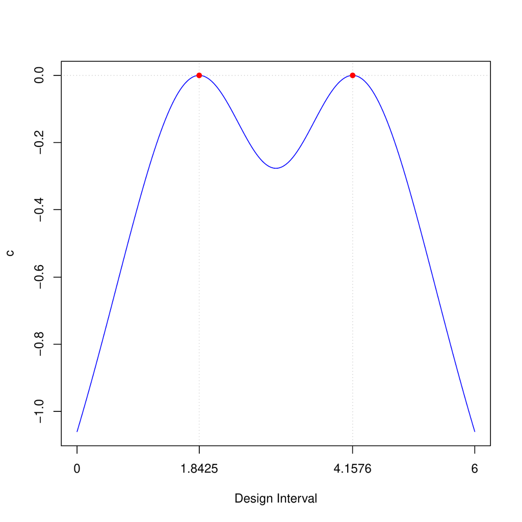

[figure not shown]

```r
R> plot(log1)
Maximum of the sensitivity function is  5.323248e-06
Efficiency lower bound (ELB) is  0.9999973
Verification required 0.33 seconds!
```

`Output from plot(log1)`

`Output from plot(log3)`

Figure 1: Plots of the sensitivity functions of the designs generated by the `locally()` function for the logistic model over *χ* = [0,6] when **θ** = **θ**<sub>0</sub> = (−4,1.3333)<sup>*T*</sup>. The left panel (a) verrfies the global optimality of the obtained design and the right panel (b) does not verify the optimality of the obtained design. The solid red dots are the values of the sensitivity function at the obtained design points.

Figure 1 (a) displays the plot of the sensitivity function @ref(eq:sensitivity-locally) of the design provided by the output on the design space $[0,6]$. Based on the equivalence theorem, this design is optimal because the sensitivity function is equal or less than zero on $[0,6]$ and (roughly) equal to zero at $1.84249$ and $4.15765$ (see the red points). The value of the ELB is nearly $1$, which also indicates the optimality of this design.

It is interesting to assess the performance of the uniform design $\xi_{uni}$ with respect to the locally $D-$optimal design obtained above. Using @ref(eq:locally-D-efficiency), we can calculate the $D-$efficiency of $\xi_{uni}$ relative to the locally $D-$optimal design by

```r
R> leff(formula = ~exp(b0 + b1 * x)/(1 + exp(b0 + b1 * x)),
+      predvars = "x", parvars = c("b0", "b1"),
+      family = "binomial", inipars = c(-4, 1.3333),
+      x1 = c(0:6), w1 = rep(1/7, 7),
+      x2 = log1$evol[[20]]$x, w2 = log1$evol[[20]]$w)
[1] 0.7778719
```

The value of the relative $D-$efficiency indicates that $\xi_{uni}$ requires about $100(1/0.777-1)= 29\%$ more number of subjects to have the same $D-$efficiency as the $D-$optimal design when $\boldsymbol{\theta}= \boldsymbol{\theta}_0$. Therefore, having subjects to practice, say, less than 1 hours or more than 5 hours will not increase the efficiency of the parameter estimates very much.

The value of the ELB may also be used to construct a stopping rule condition for ICA. This feature is activated via the `ICA.control` argument in all OD functions similar to what follows.

```r
R> log2 <- locally(formula = ~exp(b0 + b1 * x)/(1 + exp(b0 + b1 * x)),
+                 predvars = "x", parvars = c("b0", "b1"),
+                 family = "binomial", lx = 0, ux = 6, iter = 40, k = 2,
+                 inipars = c(-4, 1.3333),
+                 ICA.control = list(rseed = 1,
+                                    checkfreq = 20,
+                                    stop_rule = "equivalence",
+                                    stoptol = .99))
R> print(log2)
Finding  locally optimal designs

Call:
  ~exp(b0 + b1 * x)/(1 + exp(b0 + b1 * x))

iter       x1       x2        w1        w2 min_cost mean_cost
1     1 1.897630 4.289279 0.4480275 0.5519725 3.585707  3.629564
3     3 1.895518 4.285989 0.4875810 0.5124190 3.575159  3.616086
5     5 1.735791 4.135709 0.4818501 0.5181499 3.574277  3.608956
7     7 1.818028 4.160041 0.4797011 0.5202989 3.570617  3.570617
9     9 1.812077 4.132323 0.4965689 0.5034311 3.569134  3.569134
11   11 1.827779 4.137145 0.4958561 0.5041439 3.568919  3.568919
13   13 1.844558 4.142393 0.4961667 0.5038333 3.568856  3.568856
15   15 1.845992 4.165776 0.4984264 0.5015736 3.568713  3.568713
17   17 1.845348 4.155565 0.4996783 0.5003217 3.568688  3.568688
20   20 1.842781 4.159234 0.4999992 0.5000008 3.568680  3.568680

Optimal designs (k=2):
  Points1 Points2
1.84278 4.15923
Weights1 Weights2
0.500   0.500

ICA iteration: 20
Criterion value:  3.56868
Total number of function evaluations: 918
Total number of successful local search moves: 46
Total number of successful revolution moves: 46
Convergence: equivalence
Total number of successful assimilation moves: 345
CPU time: 0.81  seconds!

  Maximum of the sensitivity function is  3.483904e-06
Efficiency lower bound (ELB) is  0.9999983
Verification required 0.39 seconds!
  R> log2$design
iter       x1       x2        w1        w2 min_cost mean_cost     max_sens
1   20 1.842781 4.159234 0.4999992 0.5000008  3.56868   3.56868 3.483904e-06
elb time_sec
1 0.9999983     0.39
```

We set `stop_rule` = `"equivalence"` to activate the stopping rule that is based on the equivalence theorem. In this case, ICA starts to calculate the ELB for the best design every `checkfreq` = 20 iterations and it stops whenever the value of the ELB is larger than `stoptol` = 0.99. In this example, ICA stopped at the first check run because the value of ELB is 0.999 (> `stoptol`). Note that we requested to calculate the ELB after every 20 iterations, instead of every iteration, to prevent a significant increase in the CPU time. This equivalence-based stopping rule is also available in other OD functions. However, we note that optimality verification for Bayesian or minimax type criteria is more complicated and may slow down the ICA.

[*ICAOD*](https://CRAN.R-project.org/package=ICAOD) can also handle a situation where the design points are pre-specified, but their optimal associated weights are of interest. For example, assume that the experimental resources only allow a pre-specified hours of practice, say, $x_1 = 1$, $x_2 = 2$, $x_3 = 3$ hours. In all OD functions, the design points can be specified similarly via the argument `x` (a vector of design points):

```r
R> log3 <- locally(formula = ~exp(b0 + b1 * x)/(1 + exp(b0 + b1 * x)),
+                 predvars = "x", parvars = c("b0", "b1"),
+                 family = "binomial", lx = 0, ux = 6, iter = 40,
+                 x = c(1, 2, 3),
+                 inipars = c(-4, 1.3333),
+                 ICA.control = list(rseed = 1, checkfreq = Inf))

R> print(log3)
Finding  locally optimal designs

Call:
  ~exp(b0 + b1 * x)/(1 + exp(b0 + b1 * x))

iter x1 x2 x3        w1           w2        w3 min_cost mean_cost
1     1  1  2  3 0.4528099 2.460808e-03 0.5447293 4.196368  4.205840
5     5  1  2  3 0.5106454 5.660663e-03 0.4836939 4.190011  4.190011
9     9  1  2  3 0.4993132 8.104013e-05 0.5006058 4.187368  4.187368
14   14  1  2  3 0.4993694 9.602963e-06 0.5006210 4.187346  4.187346
18   18  1  2  3 0.4998314 4.227502e-06 0.5001644 4.187343  4.187343
22   22  1  2  3 0.4998286 1.079043e-07 0.5001713 4.187342  4.187342
27   27  1  2  3 0.4999951 1.656952e-08 0.5000049 4.187342  4.187342
31   31  1  2  3 0.4999982 4.628899e-10 0.5000018 4.187342  4.187342
35   35  1  2  3 0.4999994 5.689118e-11 0.5000006 4.187342  4.187342
40   40  1  2  3 0.5000001 2.449702e-12 0.4999999 4.187342  4.187342

Optimal designs (k=3):
  Weights: 0.500 0.000 0.500

ICA iteration: 40
Criterion value:  4.187342
Total number of function evaluations: 1731
Total number of successful local search moves: 39
Total number of successful revolution moves: 30
Convergence: Maximum_Iteration
Total number of successful assimilation moves: 878
CPU time: 1.22  seconds!

  Maximum of the sensitivity function is  2.558775
Efficiency lower bound (ELB) is  0.4387143
Verification required 0.35 seconds!
```

The results show that no weight should be assigned to the subjects with 2 hours of practice. This means that, the responses from subjects with 2 hours of practice will not increase the efficiency of estimation very much. Hence, this level may be eliminated to save more resources.

The value of the ELB and the plot of the sensitivity function in Figure 1 (b) clearly show that the obtained design is not globally optimal. This comes as no surprise because the given design points in `x` do not belong to the support of the optimal design when $\boldsymbol{\theta}= \boldsymbol{\theta}_0$. Note that `checkfreq = Inf` requests a `plot` method for the design provided by the output so that `plot()` is not required anymore. For space consideration, we use this option in the rest of this paper.

Locally optimal designs usually lose their efficiency when the parameter estimates are far from their true unknown values. Moreover, in practice, it is more realistic to assume that the parameters belong to a parameter space, rather than fixing their values at some points. For example, let $\boldsymbol{\theta}= (\beta_0, \beta_1)^T$ belongs to $\Theta = [\beta_0^L, \beta_0^U] \times [\beta_1^L, \beta_1^U]$, where $\beta_0^L = -6$, $\beta_0^U = -2$, $\beta_1^L = .5$ and $\beta_1^U = 2$. As a conservative strategy, a minimax $D-$optimal design minimizes the maximum inefficiency over $\Theta$. To find the minimax $D-$optimal design for our design setting, we first set $k = 2$ to find the minimax $D-$optimal design within the class of two-point designs:

```r
R> log4 <- minimax(formula = ~exp(b0 + b1 * x)/(1 + exp(b0 + b1 * x)),
+                 predvars = "x", parvars = c("b0", "b1"),
+                 family = "binomial",
+                 lx = 0, ux = 6, lp = c(-6, .5), up = c(-2, 2),
+                 iter = 200, k = 2,
+                 ICA.control = list(rseed = 1,
+                                    checkfreq = 50,
+                                    stop_rule = "equivalence",
+                                    stoptol = .99),
+                 crt.minimax.control = list(optslist = list(maxeval = 200)))
R> print(log4)
Finding  minimax optimal designs

Call:
  ~exp(b0 + b1 * x)/(1 + exp(b0 + b1 * x))

iter        x1       x2        w1        w2 min_cost mean_cost
1      1 0.4446832 4.868664 0.4243584 0.5756416 7.853582  8.061686
23    23 0.7665387 4.895727 0.4965758 0.5034242 7.782827  7.782827
45    45 0.7639494 4.895787 0.4999084 0.5000916 7.782754  7.782754
67    67 0.7636147 4.895791 0.5000079 0.4999921 7.782754  7.782754
89    89 0.7636144 4.895791 0.5000079 0.4999921 7.782754  7.782754
111  111 0.7636144 4.895791 0.5000079 0.4999921 7.782754  7.782754
133  133 0.7635408 4.895792 0.4999934 0.5000066 7.782754  7.782754
155  155 0.7635408 4.895792 0.4999934 0.5000066 7.782754  7.782754
177  177 0.7635408 4.895792 0.4999934 0.5000066 7.782754  7.782754
200  200 0.7635408 4.895792 0.4999934 0.5000066 7.782754  7.782754

Optimal designs (k=2):
  Points1 Points2
0.76354 4.89579
Weights1 Weights2
0.500   0.500

ICA iteration: 200
Criterion value:  7.782754
Total number of function evaluations: 1710132
Total number of successful local search moves: 120
Total number of successful revolution moves: 60
Convergence: Maximum_Iteration
Total number of successful assimilation moves: 1007
Vector of maximum parameter values:  -6 0.5
CPU time: 211.47  seconds!

  Maximum of the sensitivity function is  21.9395
Efficiency lower bound (ELB) is  0.08354392
Verification required 0.72 seconds!
  Adjust the control parameters in 'sens.minimax.control' ('n_seg')
or in 'sens.bayes.control' for higher speed.
```

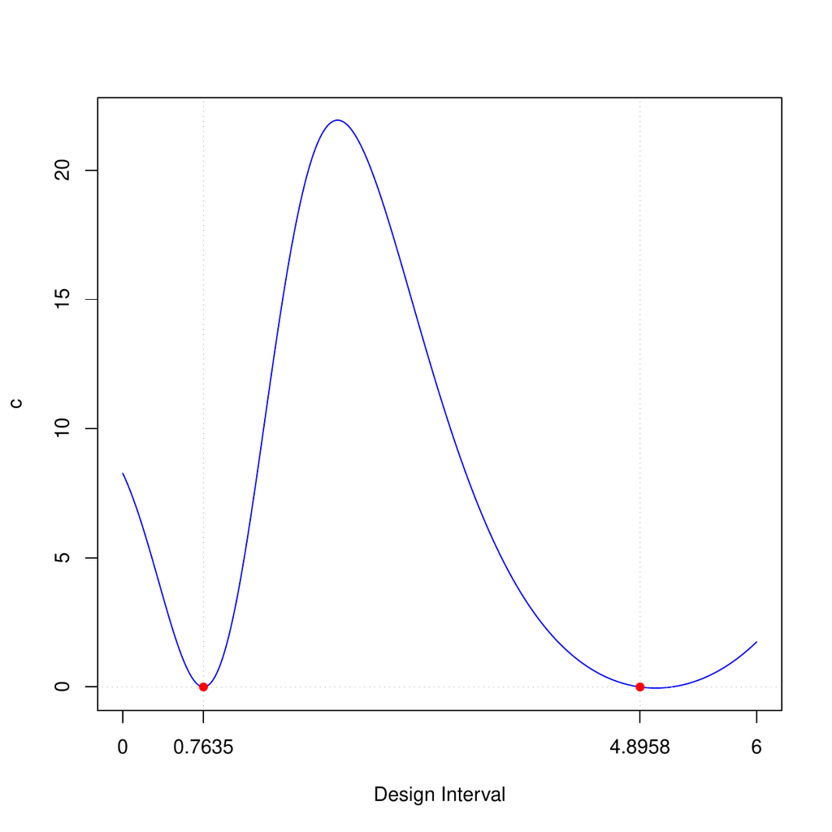

[figure not shown]

*k* = 2

*k* = 3

Figure 2: Plots of the sensitivity functions of the two- and three-point designs generated by the `minimax()` function for the logistic regression model over *χ* = [0,6] when *Θ* = [−6,−2] × [0.5,2]. The left panel (a) does not verifies the optimality of the obtained design and the right panel (b) shows the nearly optimality of the three-point design. The solid red dots are the values of the sensitivity function at the obtained design points.

Therefore, we increment the value of $k$ by one and re-execute the above code:

```r
R> log5 <- minimax(formula = ~exp(b0 + b1 * x)/(1 + exp(b0 + b1 * x)),
+                 predvars = "x", parvars = c("b0", "b1"),
+                 family = "binomial",
+                 lx = 0, ux = 6, lp = c(-6, .5), up = c(-2, 2),
+                 iter = 500, k = 3,
+                 ICA.control = list(rseed = 1,
+                                    checkfreq = 50,
+                                    stop_rule = "equivalence",
+                                    stoptol = .99),
+                 crt.minimax.control = list(optslist = list(maxeval = 200)))
R> print(log5)
Finding  minimax optimal designs

Call:
  ~exp(b0 + b1 * x)/(1 + exp(b0 + b1 * x))

iter        x1       x2       x3        w1        w2        w3 min_cost
1     1 1.0613974 2.577126 5.994463 0.1263308 0.5337391 0.3399301 6.862938
6     6 0.9212932 2.161076 5.999569 0.1092450 0.5392481 0.3515069 6.826309
11   11 0.9291691 2.163344 5.998872 0.1131382 0.4602769 0.4265849 6.760707
17   17 0.9358663 2.165053 5.998143 0.1131382 0.4602769 0.4265849 6.758872
22   22 1.0343686 2.163586 5.997440 0.1000379 0.4592324 0.4407297 6.749718
28   28 1.1201234 2.340084 5.995084 0.1526103 0.3628279 0.4845619 6.745782
33   33 1.0084352 2.232590 5.999449 0.1185027 0.3770129 0.5044843 6.738361
39   39 1.0003813 2.245542 5.999894 0.1094120 0.3941922 0.4963958 6.737553
44   44 1.0159978 2.225392 5.999982 0.1148592 0.3916467 0.4934942 6.737084
50   50 1.0269974 2.206648 5.999927 0.1135038 0.3915064 0.4949898 6.736338
mean_cost
1   7.553929
6   6.951918
11  6.805511
17  6.776728
22  6.757709
28  6.748353
33  6.743650
39  6.742541
44  6.738447
50  6.737655

Optimal designs (k=3):
  Points1 Points2 Points3
1.02700 2.20665 5.99993
Weights1 Weights2 Weights3
0.114   0.392   0.495

ICA iteration: 50
Criterion value:  6.736338
Total number of function evaluations: 511836
Total number of successful local search moves: 309
Total number of successful revolution moves: 92
Convergence: equivalence
Total number of successful assimilation moves: 407
Vector of maximum parameter values:  -6 0.5
CPU time: 71.04  seconds!

  Maximum of the sensitivity function is  0.01269528
Efficiency lower bound (ELB) is  0.9936924
Verification required 2.16 seconds!
  Adjust the control parameters in 'sens.minimax.control' ('n_seg')
or in 'sens.bayes.control' for higher speed.
R> log5$design
iter       x1       x2       x3        w1        w2        w3 min_cost
1   50 1.026997 2.206648 5.999927 0.1135038 0.3915064 0.4949898 6.736338
mean_cost   max_sens       elb time_sec
1  6.737655 0.01269528 0.9936924     2.16
```

Figure 2 (b) displays the plot of the sensitivity function of the three-point generated design and it indicates its nearly optimality. The optimal design suggests subjects with nearly $1$, $2$ and $6$ hours of practice, where roughly half of the subjects should be assigned to practice for $6$ hours.

Similar to the locally $D-$optimal design, we can assess the minimax $D-$efficiency of $\xi_{uni}$ with respect to the minimax $D-$optimal design by

```r
R> meff(formula = ~exp(b0 + b1 * x)/(1 + exp(b0 + b1 * x)),
+      predvars = "x", parvars = c("b0", "b1"),
+      family = "binomial",
+      lp = c(-6, .5), up = c(-2, 2),
+      x1 = c(0:6), w1 = rep(1/7, 7),
+      x2 = log5$evol[[20]]$x, w2 = log5$evol[[20]]$w)
[1] 0.7459795
```

## Sigmoid-Emax model

The sigmoid Emax model is commonly used in pharmacokinetics/pharamacodynamics to describe the S-shape dose-response relationship (see, e.g., Macdougall 2006; Thomas 2006). This model is defined by
$$\label{eq:sigmoid-Emax}
E(Y) = f(x, \boldsymbol{\theta}) = \beta_1 + (\beta_2-\beta_1)
\frac{x^{\beta_4}}{x^{\beta_4} +
\beta_3^{\beta_4}}, (\#eq:sigmoid-Emax)$$
where $x$ is the dose level (in mg), $x \in \chi = (0, x_0]$, $x_0$ is user-selected and $\boldsymbol{\theta}= (\beta_1, \beta_2, \beta_3, \beta_4)^T$, $\theta_2>\beta_1$, $\beta_3>0$. All errors are assumed to be independent and normally distributed with mean zero and constant variance. Here, $\beta_1$ is the minimum mean response, $\beta_2$ is the maximum mean response, $\beta_3$ is the ED50, i.e., the dose at which $50$ percent of the maximum mean effect is achieved, and $\beta_4$ is the slope parameter.

In dose-response studies, optimal designs usually determine how many doses are required to be tested, what are their levels, and how many subjects to allocate to each dose level. Let $\chi = (0, 1000]$mg. Similar to Dragalin, Hsuan, and Padmanabhan (2007) and Wang and Yang (2014), we are interested in the efficient estimation of $\boldsymbol{\theta}$ and the $D-$optimality is an appropriate design criterion for this purpose.

It is straightforward to show that the FIM of the sigmoid Emax model depends on the unknown parameters $\boldsymbol{\theta}$. This parameter dependency must be dealt with based on the type of information available on $\boldsymbol{\theta}$. For example, using information from a pilot study, one may elicit a uniform prior distribution for $\boldsymbol{\theta}$ and search for Bayesian optimal designs. As an illustrative example, let $\beta_1 \sim U(4, 8)$, $\beta_2 \sim U(11, 15)$, $\beta_3 \sim U(100, 130)$ and $\beta_4 \sim U(5, 9)$, and all the uniform prior distributions be independent. For simplicity, we denote the independent uniform distributions for $\beta_i, i = 1, 2,3, 4$ by $\pi_{\Theta}$, where $\Theta = [4, 8] \times [11, 15] \times[100,130] \times [5, 9]$ is the parameter space. This prior can be defined in [*ICAOD*](https://CRAN.R-project.org/package=ICAOD) by the `uniform()` function as follows.

```r
R> prior1 <- uniform(lower = c(4, 11, 100, 5), upper = c(8, 15, 130, 9))
```

Here, the output is an object of class ‘`cprior`’, which can be passed to the argument `prior` of the `bayes()` function.

To find the number of support points for the Bayesian $D-$optimal design, we repeated the same incremental process for finding minimax optimal design. This process is excluded here due to space consideration. The Bayesian $D-$optimal design has $5$ points in its support, which are found by

```r
R> sig1 <- bayes(formula = ~b1 + (b2-b1) * x^b4/(x^b4 + b3^b4),
+               predvars = "x",
+               parvars = c("b1", "b2", "b3", "b4"),
+               lx = .001, ux = 1000, k = 5, iter = 400, prior = prior1,
+               ICA.control = list(rseed = 1, checkfreq = Inf))
R> print(sig1)
Finding  Bayesian optimal designs

Call:
  ~b1 + (b2 - b1) * x^b4/(x^b4 + b3^b4)

iter         x1       x2       x3       x4        x5        w1        w2
1      1 18.0475346 96.25014 167.5667 179.3485  867.8058 0.2909521 0.1581145
45    45 17.4961312 89.11527 108.3659 137.0731  866.5956 0.2368958 0.1548766
89    89  0.4786294 95.25557 115.0471 138.2732  554.3556 0.2460043 0.2036432
134  134  1.0415205 94.75054 113.8961 138.3159  959.5441 0.2430275 0.1959315
178  178  0.7994201 94.64836 113.7667 138.3264  999.8505 0.2433772 0.1949845
222  222  1.8666601 94.60760 113.7090 138.3516  999.9069 0.2432310 0.1942385
267  267  0.5492615 94.60194 113.7011 138.3539  999.9987 0.2432085 0.1941306
311  311  0.4263460 94.60176 113.6966 138.3513 1000.0000 0.2432061 0.1941301
355  355  0.4164132 94.60189 113.6965 138.3510 1000.0000 0.2432041 0.1941322
400  400  0.1805450 94.60188 113.6964 138.3510 1000.0000 0.2432040 0.1941319
w3          w4        w5 min_cost mean_cost
1   0.3418695 0.006883086 0.2021808 14.10396  15.82570
45  0.1428410 0.225597557 0.2397890 12.74113  12.74774
89  0.1043130 0.200569541 0.2454699 12.72302  12.72989
134 0.1140765 0.203490785 0.2434737 12.72086  12.72095
178 0.1150226 0.203128842 0.2434868 12.72082  12.72083
222 0.1158376 0.203138347 0.2435545 12.72082  12.72082
267 0.1159406 0.203152463 0.2435679 12.72082  12.72082
311 0.1159200 0.203173666 0.2435701 12.72082  12.72082
355 0.1159159 0.203177516 0.2435702 12.72082  12.72082
400 0.1159155 0.203178189 0.2435705 12.72082  12.72082

Optimal designs (k=5):
  Points1    Points2    Points3    Points4    Points5
0.18055    94.60188   113.69639  138.35096  1000.00000
Weights1   Weights2   Weights3   Weights4   Weights5
0.243      0.194      0.116      0.203      0.244

ICA iteration: 400
Criterion value:  12.72082
Total number of function evaluations: 85150
Total number of successful local search moves: 2378
Total number of successful revolution moves: 81
Convergence: maxiter
Total number of successful assimilation moves: 1700
CPU time: 611.44  seconds!

  Maximum of the sensitivity function is  9.439815e-07
Efficiency lower bound (ELB) is  0.9999998
Verification required 65.3 seconds!
  Adjust the control parameters in 'sens.minimax.control' ('n_seg')
or in 'sens.bayes.control' for higher speed.
R> sig1$design
iter       x1       x2       x3      x4   x5       w1        w2        w3
1  400 0.180545 94.60188 113.6964 138.351 1000 0.243204 0.1941319 0.1159155
w4        w5 min_cost mean_cost     max_sens       elb time_sec
1 0.2031782 0.2435705 12.72082  12.72082 9.439815e-07 0.9999998     65.3
```

Figure 3 (a) is generated from the output and presents the plot of the sensitivity function of the five-point design and it verifies its optimality. In our example, the Bayesian $D-$optimal design suggests five dose levels, with four of them located below $140$mg and one located at the maximum. Roughly $50\%$ of the observations should be assigned to the lower and upper bound of the dose interval. Note that the result can also be obtained in lesser CPU time if we adjust the control parameters of the integral approximations via the argument `crt.bayes.control`.

Using a non-optimal design may be inefficient even when its design points are sampled uniformly from the design space. As an illustrative example, assume a situation where a researcher decides to work with an equally-weighted uniform design that has $11$ points located on $0.001, 100, 200, 300, ....,1000$. This design is not optimal when $\boldsymbol{\theta}\sim \pi_\Theta$. The Bayesian $D-$efficiency of the uniform design with respect to the obtained Bayesian $D-$optimal design is calculated by

```r
R> beff(formula = ~b1 + (b2-b1) * x ^b4/(x^b4 + b3^b4),
+      predvars = "x",
+      parvars = c("b1", "b2", "b3", "b4"),
+      prior = prior1,
+      x1 = c(.001,seq(100, 1000, by = 100)),
+      w1 = rep(1/11, 11),
+      x2 = sig1$evol[[400]]$x, w2 = sig1$evol[[400]]$w)
[1] 0.3063289
```

The non-optimal design may seem reasonable, but its Bayesian $D-$efficiency value suggests that, roughly $226\%$ more observations are needed to maintain the $D-$efficiency for the non-optimal design in comparison to the Bayesian $D-$optimal design when $\boldsymbol{\theta}\sim \pi_\Theta$. The `bayes()` function is very flexible and can incorporate different prior distributions.

[*ICAOD*](https://CRAN.R-project.org/package=ICAOD) can also find robust or optimum-on-average designs when the prior distributions are discrete. As an illustrative example, assume $\Theta_0 = \{\boldsymbol{\theta}_{01}, \boldsymbol{\theta}_{02} , \boldsymbol{\theta}_{03} , \boldsymbol{\theta}_{04} , \boldsymbol{\theta}_{05}\}$ be a set of five vectors of initial estimates for $\boldsymbol{\theta}= (\beta_1, \beta_2,\beta_3, \beta_4)$, where $\boldsymbol{\theta}_{01} = (4, 11, 100, 5)$, $\boldsymbol{\theta}_{02} = (5, 12, 110, 6)$, $\boldsymbol{\theta}_{03} = (6, 13, 120, 7)$, $\boldsymbol{\theta}_{04} = (8, 15, 130, 9)$ and $\boldsymbol{\theta}_{05} = (12, 30, 160, 13)$. Let $\pi_{\Theta_0}$ denotes a discrete uniform prior distribution that assigns the same probability to each vector element of $\Theta_0$. The six-point optimum-on-average design is given by

```r
R> parset1 <- matrix(c(4, 11, 100, 5,
+                     5, 12, 110, 6,
+                     6, 13, 120, 7,
+                     8, 15, 130, 9,
+                     12, 30, 160, 13),
+                   nrow = 5, byrow = TRUE)
R> sig2 <- robust(formula = ~b1 + (b2-b1) * x ^b4/(x^b4 + b3^b4),
+                predvars = "x",
+                parvars = c("b1", "b2", "b3", "b4"),
+                lx = .001, ux = 1000, k = 6, iter = 400,
+                parset = parset1,
+                prob = rep(1/5, 5),
+                ICA.control = list(rseed = 1, checkfreq = Inf))
R> print(sig2)
Finding  robust or optimum-on-average optimal designs

Call:
  ~b1 + (b2 - b1) * x^b4/(x^b4 + b3^b4)

iter          x1       x2       x3       x4       x5        x6        w1
1      1 52.47474098 86.13143 108.6089 176.5576 847.1196  865.1056 0.3356308
45    45  0.03699118 93.84970 115.0752 144.3279 172.2496  612.5133 0.1921861
89    89  0.26057011 86.13743 112.6560 143.7663 170.6661  899.7495 0.1938690
134  134  0.27440675 86.41506 112.7178 143.7321 170.5697  999.4115 0.1997277
178  178  0.42978429 86.41957 112.7179 143.7262 170.5713  999.5817 0.2001652
222  222  0.86217693 86.41953 112.7092 143.7262 170.5733  999.9999 0.2001538
267  267  0.78134061 86.42156 112.7098 143.7250 170.5722 1000.0000 0.2001708
311  311  0.28372653 86.42155 112.7098 143.7248 170.5723 1000.0000 0.2001738
355  355  0.08123600 86.42156 112.7099 143.7248 170.5723 1000.0000 0.2001734
400  400  0.04980091 86.42158 112.7099 143.7248 170.5723 1000.0000 0.2001734
w2        w3        w4         w5        w6 min_cost mean_cost
1   0.06870259 0.1056298 0.2022530 0.12858302 0.1592008 14.10402  16.35115
45  0.15186984 0.1444531 0.2155502 0.08196997 0.2139708 12.25422  12.31711
89  0.13222946 0.1570768 0.1882862 0.09776625 0.2307723 12.21447  12.28391
134 0.13190606 0.1549309 0.1855214 0.09816873 0.2297452 12.21398  12.28328
178 0.13154222 0.1547794 0.1858112 0.09840028 0.2293017 12.21398  12.28311
222 0.13149988 0.1548130 0.1857954 0.09845378 0.2292841 12.21398  12.28305
267 0.13150916 0.1547914 0.1857821 0.09847028 0.2292762 12.21398  12.27535
311 0.13150554 0.1547882 0.1857820 0.09847434 0.2292761 12.21398  12.26001
355 0.13150671 0.1547883 0.1857817 0.09847396 0.2292760 12.21398  12.21398
400 0.13150681 0.1547882 0.1857817 0.09847394 0.2292759 12.21398  12.21398

Optimal designs (k=6):
  Points1    Points2    Points3    Points4    Points5    Points6
0.04980    86.42158   112.70988  143.72485  170.57227  1000.00000
Weights1   Weights2   Weights3   Weights4   Weights5   Weights6
0.200      0.132      0.155      0.186      0.098      0.229

ICA iteration: 400
Criterion value:  12.21398
Total number of function evaluations: 20070
Total number of successful local search moves: 3787
Total number of successful revolution moves: 88
Convergence: Maximum_Iteration
Total number of successful assimilation moves: 1895
CPU time: 29.56  seconds!

  Maximum of the sensitivity function is  3.960066e-07
Efficiency lower bound (ELB) is  0.9999999
Verification required 2.27 seconds!
  R> sig2$design
iter         x1       x2       x3       x4       x5   x6        w1        w2
1  400 0.04980091 86.42158 112.7099 143.7248 170.5723 1000 0.2001734 0.1315068
w3        w4         w5        w6 min_cost mean_cost     max_sens
1 0.1547882 0.1857817 0.09847394 0.2292759 12.21398  12.21398 3.960066e-07
elb time_sec
1 0.9999999     2.27
```

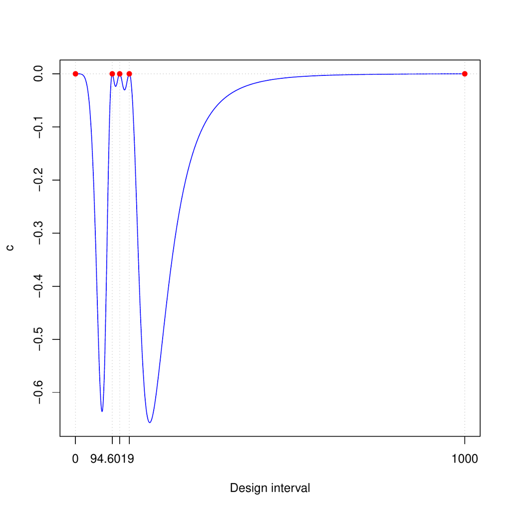

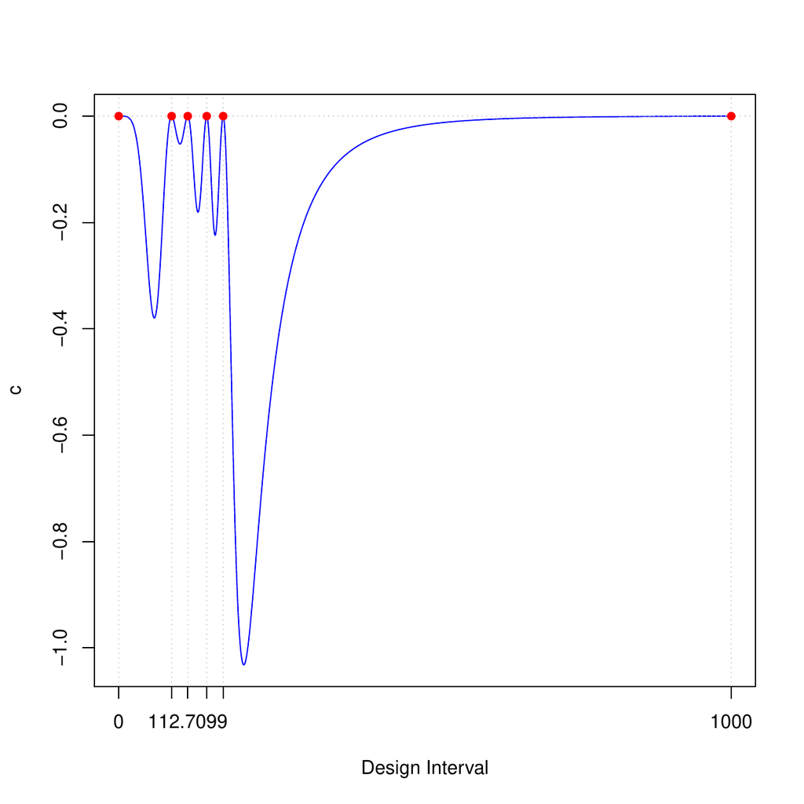

**θ** ∼ *π*<sub>*Θ*</sub>

**θ** ∼ *π*<sub>*Θ*<sub>0</sub></sub>

Figure 3: The plots of sensitivity functions of the generated designs for the sigmoid Emax model over the design space $[0.001,1000]$. The left panel (a) displays the plot of the sensitivity function of the design generated by the function `bayes()` when **θ** ∼ *π*<sub>*Θ*</sub>. The right panel (b) displays the plot of the sensitivity function of the design generated by the function `robust()` when **θ** ∼ *π*<sub>*Θ*<sub>0</sub></sub>. Both (a) and (b) verify the optimality of the obtained design. The solid red dots are the values of the sensitivity function at the obtained design points.

Figure 3 (b) displays the plot of the sensitivity function of the design provided by the output and it verifies the optimality of the six-point design. Similar to the optimal design generated by `bayes()`, the generated design here allocates most of its support points to the lower half of the dose interval.

# User-specified optimality criteria

[*ICAOD*](https://CRAN.R-project.org/package=ICAOD) can also find optimal designs with respect to user-specified optimality criteria. In this section, as an illustrative example, we find $c-$optimal designs for the two-parameter logistic (2PL) model with applications in dose-response studies. The 2PL model is commonly used in dose-response studies to model the relationship between the dose level of a drug and the probability of a success, e.g., the probability that patients are cured. This model is defined by
$$\label{eq:logistic-model}
f(x, \boldsymbol{\theta}) = P(Y=1) = \frac{1}{1 +
\exp(-b(x-a))}, (\#eq:logistic-model)$$
where $x$ is the dose level (predictor), $\boldsymbol{\theta}= (a, b)^T$, $b$ is the slope parameter and $a$ is the dose level at which the response probability is $0.5$ (ED50). Throughout this paper, we denote the dose level at which the response probability is equal to $\pi$ by ED$100\pi$. For the 2PL model, it can be shown that ED$100\pi$ is equal to $c(\boldsymbol{\theta}) = a + \gamma b^{-1}$, where $\gamma = \log[\pi/(1-\pi)]$ (see, e.g., Zhu and Wong 2001).

Sometimes the purpose of a study is to estimate a function of the unknown parameters, say, ED$100\pi$, rather than estimating all the parameters simultaneously. For example, in heart defibrillator design problems, estimating the ED95, or equivalently, estimating $c(\boldsymbol{\theta}) = a + \log(0.95/(1-0.95)) b^{-1}$ for the 2PL model is of interest (Clyde, Müller, and Parmigiani 1995). In this case, a reasonable optimality criterion is the one that minimizes the asymptotic variance of the maximum likelihood (ML) estimator of $c(\boldsymbol{\theta})$, which is proportional to
$$\label{eq:c-criterion}
\psi^c(\xi, \boldsymbol{\theta}) = \nabla^T
c(\boldsymbol{\theta})M^{-1}(\xi, \boldsymbol{\theta})\nabla
c(\boldsymbol{\theta}), (\#eq:c-criterion)$$
where $\nabla c(\boldsymbol{\theta})$ is the gradient of $c(\boldsymbol{\theta})$ and $M^{-1}(\xi, \boldsymbol{\theta})$ is the inverse of the FIM (see, e.g., Silvey 1980, 4). For the 2PL model, $\nabla c(\boldsymbol{\theta}) = (1, -\gamma b^{-2})^T$. In the optimal design literature, $\psi^c(\xi, \boldsymbol{\theta})$ is referred to as $c-$optimality criterion and a design that minimizes $\psi^c(\xi, \boldsymbol{\theta})$ is called $c-$optimal design. An equivalence theorem is also available for $c-$optimality: a design $\xi^*_{c}$ is $c-$optimal among all the designs on $\chi$ if and only if the following inequality holds for all $x \in \chi$,
$$\label{eq:c-criterion-sensitivity}
c^c(x, \xi^*_{c}) = \mathop{\mathrm{tr}}(B(\boldsymbol{\theta})
M^{-1}(\xi, \boldsymbol{\theta})M(\xi_x, \boldsymbol{\theta})M^{-1}(\xi,
\boldsymbol{\theta})) - \psi^c(\xi, \boldsymbol{\theta}) \leq
0, (\#eq:c-criterion-sensitivity)$$
with equality in @ref(eq:c-criterion-sensitivity) for all the support points of $\xi^*_{c}$ (see, e.g., Chaloner and Larntz 1989). Here, $B(\boldsymbol{\theta}) = \nabla^T c(\boldsymbol{\theta})\nabla c(\boldsymbol{\theta})$ and $\xi_x$ denotes a degenerate design that puts all its mass on $x$.

Similar to the $D-$optimality criterion, $c-$optimality also depends on the unknown parameters and different types of optimal designs may be found, depending on how to deal with the unknown parameters. As benchmark examples, in this section, we find locally and Bayesian $c-$optimal designs for estimating the ED95 for the 2PL model when $\chi = [-1, 1]$. These examples are also available in Chaloner and Larntz (1989). Finding a minimax $c-$optimal or a robust design is very similar and is excluded due to space consideration.

To use [*ICAOD*](https://CRAN.R-project.org/package=ICAOD) for finding $c-$optimal designs, the user should first define the $c-$optimality criterion and its sensitivity function as two separate functions in the R environment. Later, these functions will be passed to `bayes()`, `minimax()`, `locally()` and `robust()` via the `crtfunc` and `sensfunc` arguments, respectively. For example, given the 2PL model with parameters `parvars = c("a", "b")`, the following lines of codes define @ref(eq:c-criterion) and @ref(eq:c-criterion-sensitivity) in the R environment to be used in `locally()`, `minimax()` and `robust()`.

```r
R> c_opt <-function(x, w, a, b, fimfunc){
+   gam <- log(.95/(1-.95))
+   M <- fimfunc(x = x, w = w, a = a, b = b)
+   c <- matrix(c(1, -gam * b^(-2)), nrow = 1)
+   B <- t(c) %*% c
+   sum(diag(B %*% solve(M)))
+ }

R> c_sens <- function(xi_x, x, w, a, b, fimfunc){
+   gam <- log(.95/(1-.95))
+   M <- fimfunc(x = x, w = w, a = a, b = b)
+   M_inv <- solve(M)
+   M_x <- fimfunc(x = xi_x, w = 1, a = a, b = b)
+   c <- matrix(c(1, -gam * b^(-2)), nrow = 1)
+   B <- t(c) %*% c
+   sum(diag(B %*% M_inv %*% M_x %*%  M_inv)) - sum(diag(B %*% M_inv))
+ }
```

The arguments `x`, `w` are, respectively, the vector of design points and their associated weights defined by @ref(eq:eq-approximate-design). `fimfunc()` is a function with arguments `x`, `w`, `a` and `b` that returns the evaluated FIM as a `matrix` and `xi_x` denotes a degenerate design, which has the same length as the number of model predictors. The arguments `a` and `b` are model-specific and denote the parameters of the model that is specified via `parvars`. A convenient feature of [*ICAOD*](https://CRAN.R-project.org/package=ICAOD) is that there is no need to compute the FIM of the model even for a user-specified optimality criterion and the user can apply the internally-created FIM within the body of `c_opt()` and `c_sens()` using `fimfunc()`. Note that both of the `c_opt()` and `c_sens()` functions are not vectorized with respect to `a` and `b`. This means that `fimfunc()` returns only a `matrix`, and `c_opt()` and `c_sens()` return a value. This is a necessary structure required by the `locally()`, `minimax()` and `robust()` functions. The following lines of codes provide the locally $c-$optimal design for estimating the ED95 when $\boldsymbol{\theta}= (0, 7)$.

```r
R> twoPL1 <- locally(formula = ~1/(1 + exp(-b * (x-a))), predvars = "x",
+                   parvars = c("a", "b"), family = "binomial",
+                   lx = -1, ux = 1, inipars = c(0, 7),
+                   iter = 100, k = 2,
+                   crtfunc = c_opt, sensfunc = c_sens,
+                   ICA.control = list(rseed = 1, checkfreq = Inf))
R> print(twoPL1)
Finding  locally optimal designs

Call:
  ~1/(1 + exp(-b * (x - a)))

iter         x1        x2         w1        w2  min_cost mean_cost
1      1 -0.5925888 0.3010654 0.18893987 0.8110601 0.4610712 0.5538651
12    12 -0.3542959 0.3287717 0.11649268 0.8835073 0.4038230 0.4152469
23    23 -0.3319221 0.3409457 0.09387297 0.9061270 0.4028975 0.4061873
34    34 -0.3427433 0.3430464 0.09225956 0.9077404 0.4028270 0.4030954
45    45 -0.3427747 0.3427851 0.09254018 0.9074598 0.4028266 0.4028356
56    56 -0.3427642 0.3427662 0.09255921 0.9074408 0.4028266 0.4028277
67    67 -0.3427648 0.3427655 0.09256089 0.9074391 0.4028266 0.4028271
78    78 -0.3427653 0.3427653 0.09256118 0.9074388 0.4028266 0.4028268
89    89 -0.3427653 0.3427653 0.09256120 0.9074388 0.4028266 0.4028267
100  100 -0.3427653 0.3427653 0.09256119 0.9074388 0.4028266 0.4028266

Optimal designs (k=2):
  Points1  Points2
-0.34277 0.34277
Weights1 Weights2
0.093    0.907

ICA iteration: 100
Criterion value:  0.4028266
Total number of function evaluations: 4764
Total number of successful local search moves: 415
Total number of successful revolution moves: 65
Convergence: Maximum_Iteration
Total number of successful assimilation moves: 1157
CPU time: 4.09  seconds!

  Maximum of the sensitivity function is  1.181344e-09
Efficiency lower bound (ELB) is  1
Verification required 0.69 seconds!
  R> twoPL1$design
iter         x1        x2         w1        w2  min_cost mean_cost
1  100 -0.3427653 0.3427653 0.09256119 0.9074388 0.4028266 0.4028266
max_sens elb time_sec
1 1.181344e-09   1     0.69
```

The obtained design suggests that nearly $90\%$ of the observations should be assigned to $0.34277$ and the rest should be allocated to $-0.34277$. Figure 4 (a) displays the plot of the sensitivity function of the obtained design and it indicates its optimality. Using the given `c_opt()` and `c_sens()` functions, we can similarly find minimax $c-$optimal or robust designs. For illustrating example, see `?minimax` and `?robust`.

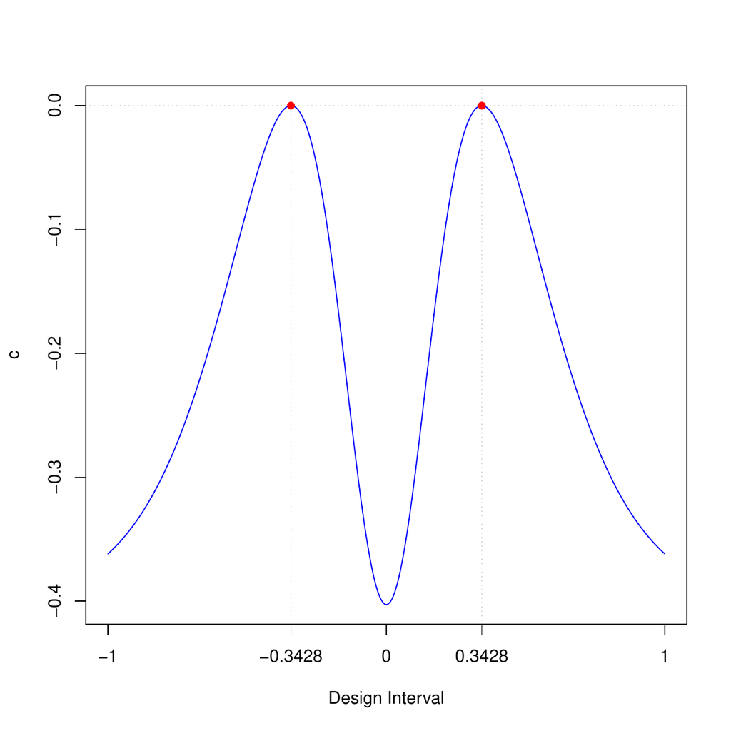

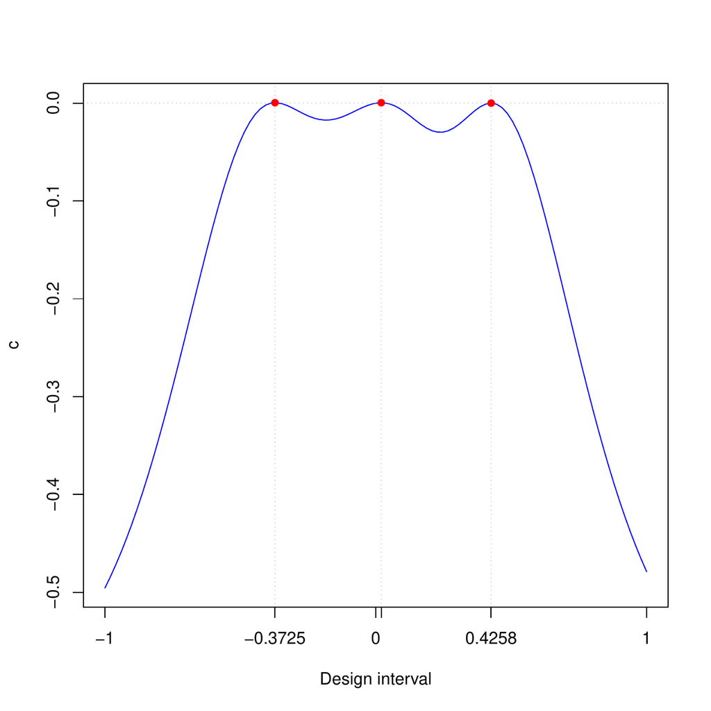

`Output from plot(twoPL1)`

`Output from plot(twoPL2)`

Figure 4: Plots of the sensitivity functions of the generated *c*−optimal designs for estimating the ED95 when *x* ∈ *χ* = [−1,1]. The left panel (a) displays the sensitivity function of the locally *c*−optimal design when $θ = (0,7)$. The right panel (b) displays the sensitivity function of the Bayesian *c*−optimal design when *a* ∼ *U*(−0.3,0.3) and *b* ∼ *U*(6,8). Both (a) and (b) verify the optimality of the obtained designs. The solid red dots are the values of the sensitivity function at the obtained design points.

Finding Bayesian $c-$optimal design is very similar, except that each of @ref(eq:c-criterion) and @ref(eq:c-criterion-sensitivity) must be a vectorized R `function` with respect to the model parameters `a` and `b`:

```r
R> c_opt_vec <-function(x, w, a, b, fimfunc){
+   gam <- log(.95/(1-.95))
+   M <- fimfunc(x = x, w = w, a = a, b = b)
+   B <- sapply(1:length(M), FUN = function(i)
+     matrix(c(1, -gam * b[i]^(-2)), ncol= 1) %*%
+       matrix(c(1, -gam * b[i]^(-2)), nrow = 1), simplify = FALSE)
+   sapply(1:length(M), FUN = function(i)
+     sum(diag(B[[i]] %*% solve(M[[i]]))))
+ }
R> c_sens_vec <- function(xi_x, x, w, a, b, fimfunc){
+   gam <- log(.95/(1-.95)) # LD .95
+   M <- fimfunc(x = x, w = w, a = a, b = b)
+   M_inv <- lapply(M , FUN = function(FIM) solve(FIM))
+   M_x <- fimfunc(x = xi_x, w = 1, a = a, b = b)
+   B <- sapply(1:length(M), FUN = function(i)
+     matrix(c(1, -gam * b[i]^(-2)), ncol= 1) %*%
+       matrix(c(1, -gam * b[i]^(-2)), nrow = 1), simplify = FALSE)
+   sapply(1:length(M), FUN = function(i)
+     sum(diag(B[[i]] %*% M_inv[[i]] %*% M_x[[i]] %*% M_inv[[i]])) -
+       sum(diag(B[[i]] %*% M_inv[[i]])))
+ }
```

In the `c_opt_vec` and `c_sens_vec` functions, the arguments `a` and `b` are now vectors of the same (dynamic) length, and `fimfunc()` now returns a `list` of matrices with length equal to `length(a)`. Let $a\sim U(-0.3, 0.3)$ and $b \sim U(6, 8)$. Given `c_opt_vec` and `c_sens_vec`, the Bayesian $c-$optimal design for estimating the ED95 is obtained by

```r
R> twoPL2 <- bayes(formula = ~1/(1 + exp(-b * (x-a))), predvars = "x",
+                 parvars = c("a", "b"), family = "binomial",
+                 lx = -1, ux = 1,
+                 prior = uniform(lower = c(-.3, 6), upper  = c(.3, 8)),
+                 iter = 100, k = 3,
+                 crtfunc = c_opt_vec,
+                 sensfunc = c_sens_vec,
+                 ICA.control = list(rseed = 1, ncount = 60, checkfreq = Inf),
+                 sens.bayes.control = list(cubature = list(maxEval = 100)))
R> print(twoPL2)
Finding  Bayesian optimal designs

Call:
  ~1/(1 + exp(-b * (x - a)))

iter           x1         x2        x3         w1        w2        w3
1      1 -0.004009039 0.29828119 0.4605856 0.19080601 0.3821834 0.4270106
12    12  0.004988270 0.40974945 0.4383355 0.20244712 0.2165999 0.5809529
23    23 -0.353135960 0.03376940 0.4250446 0.04238018 0.2424870 0.7151328
34    34 -0.351030679 0.03608485 0.4284948 0.04107568 0.2404412 0.7184831
45    45 -0.370795161 0.02795782 0.4282277 0.03956796 0.2269339 0.7334982
56    56 -0.326444221 0.02699155 0.4266908 0.02763386 0.2197316 0.7526345
67    67 -0.359979100 0.02467998 0.4271671 0.02883547 0.2165489 0.7546157
78    78 -0.374296800 0.02160651 0.4265674 0.02691817 0.2180796 0.7550023
89    89 -0.372327659 0.01982217 0.4257716 0.02629106 0.2186265 0.7550825
100  100 -0.372518847 0.02002258 0.4257626 0.02640997 0.2186892 0.7549009
min_cost mean_cost
1   0.6555717 0.7701302
12  0.6288037 0.6371994
23  0.6267816 0.6297125
34  0.6265897 0.6281724
45  0.6258766 0.6279520
56  0.6254187 0.6278212
67  0.6253270 0.6277844
78  0.6252741 0.6277719
89  0.6252610 0.6277691
100 0.6252608 0.6277691

Optimal designs (k=3):
  Points1  Points2  Points3
-0.37252 0.02002  0.42576
Weights1 Weights2 Weights3
0.026    0.219    0.755

ICA iteration: 100
Criterion value:  0.6252608
Total number of function evaluations: 38461
Total number of successful local search moves: 1087
Total number of successful revolution moves: 134
Convergence: maxiter
Total number of successful assimilation moves: 1115
CPU time: 203.82  seconds!

  Maximum of the sensitivity function is  0.0003369562
Efficiency lower bound (ELB) is  0.9998316
Verification required 3.56 seconds!
  Adjust the control parameters in 'sens.minimax.control' ('n_seg')
or in 'sens.bayes.control' for higher speed.
R> twoPL2$design
iter         x1         x2        x3         w1        w2        w3  min_cost
1  100 -0.3725188 0.02002258 0.4257626 0.02640997 0.2186892 0.7549009 0.6252608
mean_cost     max_sens       elb time_sec
1 0.6277691 0.0003369562 0.9998316     3.56
```

Figure 4 (b) displays the plot of the sensitivity function of the design provided by the output and it verifies its optimality. Similar to the locally $c-$optimal design, this design puts more than $97\%$ of its weight on the positive support points.

# Summary

[*ICAOD*](https://CRAN.R-project.org/package=ICAOD) modifies a state-of-the-art metaheuristic algorithm called Imperialist Competitive Algorithm to find different types of optimal designs for nonlinear models. We believe this package is more self-contained and has more capability than the few available in the literature. In particular, [*ICAOD*](https://CRAN.R-project.org/package=ICAOD) offers different design approaches for handling the parameter dependency in the information matrix when the model is nonlinear. A useful feature of the [*ICAOD*](https://CRAN.R-project.org/package=ICAOD) package is that it can create the Fisher information matrices for a very general class of nonlinear models automatically and also includes useful theory-based tools to assess proximity of any design to the optimal design without knowing the latter. Using [*ICAOD*](https://CRAN.R-project.org/package=ICAOD), it is also possible to find optimal designs for a user-specified optimality criterion, including hard-to-find various types of minimax optimal designs for which the criterion is not differentiable.

Due to space consideration, we presented only a few examples in this paper to show the functionality of the package. The help-documentation manual for the package contains further details and illustrations. We hope that the generality and simplicity of the [*ICAOD*](https://CRAN.R-project.org/package=ICAOD) package will encourage researchers from different disciplines to explore optimal design ideas in their work and enable them to implement a more informed design to realize maximum statistical efficiency at minimal cost.

# Computational details

The results in this paper were obtained using R 4.0.2 with the [*ICAOD*](https://CRAN.R-project.org/package=ICAOD) 1.0.1 package. R itself and all packages used are available from the Comprehensive R Archive Network (CRAN) at https://CRAN.R-project.org/.

# Acknowledgments

We would like to thank Dr. Paul-Christian Bürkner for his helpful comments when writing the package and this manuscript. The research of Wong reported in this paper was partially supported by a grant award R01GM107639 from the National Institute of General Medical Sciences of the National Institutes of Health. The research of Holling and Masoudi in this paper was partially supported by a grant (HO 1286/6 - 4) of the German Research Foundation (DFG). The research of Kim reported in this paper was partially supported by grant awards R21GM140352 from the National Institute of General Medical Sciences and P30CA022453 from the National Cancer Institute of the National Institutes of Health. The contents in this paper are solely the responsibility of the authors and do not necessarily represent the official views of the National Institutes of Health.

# Disclosure

Ehsan Masoudi is an employee of Roche Pharma AG in Germany since October 2019.

Abdelbasit, K. M., and R. L. Plackett. 1983. “Experimental Design for Binary Data.” *Journal of the American Statistical Association* 78 (381): 90–98. https://doi.org/10.1080/01621459.1983.10477936.

Atashpaz-Gargari, Esmaeil, and Caro Lucas. 2007. “Imperialist Competitive Algorithm: An Algorithm for Optimization Inspired by Imperialistic Competition.” In *IEEE Congress on Evolutionary Computation*, 4661–67. https://doi.org/10.1109/CEC.2007.4425083.

Atkinson, A. C. 1996. “The Usefulness of Optimum Experimental Designs.” *Journal of the Royal Statistical Society B* 58: 59–76. https://doi.org/10.1111/j.2517-6161.1996.tb02067.x.

Atwood, Corwin L. 1969. “Optimal and Efficient Designs of Experiments.” *The Annals of Mathematical Statistics* 40 (5): 1570–1602. https://doi.org/10.1214/aoms/1177697374.

Berger, Martijn PF, CY Joy King, and Weng Kee Wong. 2000. “Minimax D-Optimal Designs for Item Response Theory Models.” *Psychometrika* 65 (3): 377–90. https://doi.org/10.1007/BF02296152.

Berger, Martijn PF, and W. K. Wong. 2005. *Applied Optimal Designs*. Jonh Wiley & Sons, Chichester, West Sussex, UK. https://doi.org/10.1002/0470857005.

———. 2009. *An Introduction to Optimal Designs for Social and Biomedical Research*. Jonh Wiley & Sons, Chichester, West Sussex, UK. https://doi.org/10.1002/9780470746912.

Berntsen, Jarle, Terje O Espelid, and Alan Genz. 1991. “An Adaptive Algorithm for the Approximate Calculation of Multiple Integrals.” *ACM Transactions on Mathematical Software (TOMS)* 17 (4): 437–51. https://doi.org/10.1145/210232.210233.

Bürkner, Paul-Christian, Rainer Schwabe, and Heinz Holling. 2019. “Optimal Designs for the Generalized Partial Credit Model.” *British Journal of Mathematical and Statistical Psychology*. https://doi.org/10.1111/bmsp.12148.

Chaloner, Kathryn, and Kinley Larntz. 1989. “Optimal Bayesian Design Applied to Logistic Regression Experiments.” *Journal of Statistical Planning and Inference* 21 (2): 191–208. https://doi.org/10.1016/0378-3758(89)90004-9.

Chaloner, Kathryn, and Isabella Verdinelli. 1995. “Bayesian Experimental Design: A Review.” *Statistical Science* 10 (3): 273–304. https://doi.org/10.1214/ss/1177009939.

Chernoff, Herman. 1953. “Locally Optimal Designs for Estimating Parameters.” *The Annals of Mathematical Statistics* 24 (4): 586–602. https://doi.org/10.1214/aoms/1177728915.

Clyde, Merlise, Peter Müller, and Giovanni Parmigiani. 1995. “Optimal Design for Heart Defibrillators.” In *Case Studies in Bayesian Statistics, Volume II*, 278–92. Springer. https://doi.org/10.1007/978-1-4612-2546-1_7.

Dette, Holger, Christine Kiss, Mirjana Bevanda, and Frank Bretz. 2010. “Optimal Designs for the EMAX, Log-Linear and Exponential Models.” *Biometrika* 97 (2): 513–18. https://doi.org/10.1093/biomet/asq020.

Dragalin, Vladimir, Francis Hsuan, and S Krishna Padmanabhan. 2007. “Adaptive Designs for Dose-Finding Studies Based on Sigmoid e Max Model.” *Journal of Biopharmaceutical Statistics* 17 (6): 1051–70. https://doi.org/10.1080/10543400701643954.

Fedorov, V. V. 1980. “Convex Design Theory.” *Series Statistics* 11 (3): 403–13. https://doi.org/10.1080/02331888008801549.

Fedorov, Valerii V, and Peter Hackl. 2012. *Model-Oriented Design of Experiments*. Vol. 125. Springer Science & Business Media. https://doi.org/10.1007/978-1-4612-0703-0.

Fedorov, Valerii V, and Sergei L Leonov. 2013. *Optimal Design for Nonlinear Response Models*. CRC Press.

Firth, D, and JP Hinde. 1997. “On Bayesian d-Optimum Design Criteria and the Equivalence Theorem in Non-Linear Models.” *Journal of the Royal Statistical Society B* 59 (4): 793–97. https://doi.org/10.1111/1467-9868.00096.

Gablonsky, Joerg M, and C Tim Kelley. 2001. “A Locally-Biased Form of the DIRECT Algorithm.” *Journal of Global Optimization* 21 (1): 27–37. https://doi.org/10.1023/A:1017930332101.

Genz, A. C., and A. A. Malik. 1980. “Remarks on Algorithm 006: An Adaptive Algorithm for Numerical Integration over an n-Dimensional Rectangular Region.” *Journal of Computational and Applied Mathematics* 6 (4): 295–302. https://doi.org/10.1016/0771-050X(80)90039-X.

Graßhoff, Ulrike, Heinz Holling, and Rainer Schwabe. 2012. “Optimal Designs for the Rasch Model.” *Psychometrika* 77 (4): 710–23. https://doi.org/10.1007/s11336-012-9276-2.

Holling, Heinz, and Rainer Schwabe. 2013. “An Introduction to Optimal Design: Some Basic Issues Using Examples from Dyscalculia Research.” *Zeitschrift für Psychologie* 221 (3): 124.

Hosseini, Seyedmohsen, and Abdullah Al Khaled. 2014. “A Survey on the Imperialist Competitive Algorithm Metaheuristic: Implementation in Engineering Domain and Directions for Future Research.” *Applied Soft Computing* 24: 1078–94. https://doi.org/10.1016/j.asoc.2014.08.024.

Hyun, Seung Won, Weng Kee Wong, and Yarong Yang. 2018. “VNM: An R Package for Finding Multiple-Objective Optimal Designs for the 4-Parameter Logistic Model.” *Journal of Statistical Software* 83 (5): 1–19. https://doi.org/10.18637/jss.v083.i05.

Johnson, Steven G. 2013. “Cubature Package.” https://github.com/stevengj/cubature.

———. 2014. “The NLopt Nonlinear-Optimization Package.” http://ab-initio.mit.edu/nlopt.

Kennedy, J., and R. Eberhart. 1995. “Particle Swarm Optimization.” In *Proceedings of ICNN’95 - International Conference on Neural Networks*, 4:1942–1948 vol.4. https://doi.org/10.1109/ICNN.1995.488968.

Kiefer, Jack, and Jacob Wolfowitz. 1959. “Optimum Designs in Regression Problems.” *The Annals of Mathematical Statistics* 30: 271–94. https://doi.org/10.1214/aoms/1177706252.

King, Joy, and Weng Kee Wong. 2000. “Minimax D-Optimal Designs for the Logistic Model.” *Biometrics* 56 (4): 1263–67.

Lehmann, Erich Leo, and George Casella. 1998. *Theory of Point Estimation*. Vol. 31. Springer Science & Business Media.

Lin, Jun Lin, Chun Wei Cho, and Hung Chjh Chuan. 2013. “Imperialist Competitive Algorithms with Perturbed Moves for Global Optimization.” In *Applied Mechanics and Materials*, 284:3135–39. Trans Tech Publ. https://doi.org/10.4028/www.scientific.net/amm.284-287.3135.

Macdougall, James. 2006. “Analysis of Dose–Response Studies–e Max Model.” In *Dose Finding in Drug Development*, 127–45. New York, NY: Springer. https://doi.org/10.1007/0-387-33706-7_9.

Masoudi, Ehsan, Heinz Holling, Belmiro P. M. Duarte, and Weng Kee Wong. 2019. “Metaheuristic Adaptive Cubature Based Algorithm to Find Bayesian Optimal Designs for Nonlinear Models.” *Journal of Computational and Graphical Statistics*. https://doi.org/10.1080/10618600.2019.1601097.

Masoudi, Ehsan, Heinz Holling, and Weng Kee Wong. 2017. “Application of Imperialist Competitive Algorithm to Find Minimax and Standardized Maximin Optimal Designs.” *Computational Statistics & Data Analysis* 113: 330–45. https://doi.org/10.1016/j.csda.2016.06.014.

Masoudi, Ehsan, Heinz Holling, Weng Kee Wong, and Seongho Kim. 2020. “ICAOD: Optimal Designs for Nonlinear Models.” http://CRAN.R-project.org/package=ICAOD.

Masoudi, Ehsan, Majid Sarmad, and Hooshang Talebi. 2013. *LDOD: Finding Locally D-Optimal Optimal Designs for Some Nonlinear and Generalized Linear Models.* http://CRAN.R-project.org/package=LDOD.

Narasimhan, Balasubramanian, and Steven G. Johnson. 2017. “Cubature: Adaptive Multivariate Integration over Hypercubes.” https://CRAN.R-project.org/package=cubature.

Overstall, Antony M, and David C Woods. 2017. “Bayesian Design of Experiments Using Approximate Coordinate Exchange.” *Technometrics* 59 (4): 458–70. https://doi.org/10.1080/00401706.2016.1251495.

Overstall, Antony, David Woods, and Maria Adamou. 2017. “Acebayes: An r Package for Bayesian Optimal Design of Experiments via Approximate Coordinate Exchange.” [arXiv preprint arXiv:1705.08096](https://arXiv%20preprint%20arXiv:1705.08096).

Pázman, Andrej. 1986. *Foundations of Optimum Experimental Design*. Vol. 14. Springer.

Pukelsheim, Friedrich, and Sabine Rieder. 1992. “Efficient Rounding of Approximate Designs.” *Biometrika* 79 (4): 763–70. https://doi.org/10.2307/2337232.

SAS Institute Inc. 2016. *JMP 13 Design of Experiments Guide*. Cary, NC: SAS Institute Inc. https://www.jmp.com.

Silvey, S. D. 1980. *Optimal Design : An Introduction to the Theory for Parameter Estimation*. London; New York : Chapman; Hall. https://doi.org/10.1007/978-94-009-5912-5.

Sitter, R. R. 1992. “Robust Designs for Binary Data.” *Biometrics* 48 (4): 1145–55. https://doi.org/10.2307/2532705.

Thomas, Neal. 2006. “Hypothesis Testing and Bayesian Estimation Using a Sigmoid e Max Model Applied to Sparse Dose-Response Designs.” *Journal of Biopharmaceutical Statistics* 16 (5): 657–77. https://doi.org/10.1080/10543400600860469.

Wang, Tianhua, and Min Yang. 2014. “Adaptive Optimal Designs for Dose-Finding Studies Based on Sigmoid Emax Models.” *Journal of Statistical Planning and Inference* 144: 188–97. https://doi.org/10.1016/j.jspi.2013.09.003.

Weiser, Constantin. 2016. “mvQuad: Methods for Multivariate Quadrature.” http://CRAN.R-project.org/package=mvQuad.

Wong, Weng Kee. 1992. “A Unified Approach to the Construction of Minimax Designs.” *Biometrika* 79 (3): 611–19. https://doi.org/doi.org/10.1093/biomet/79.3.611.

Yang, Xin-She. 2011. “Metaheuristic Optimization: Algorithm Analysis and Open Problems.” In *Experimental Algorithms*, edited by Panos M. Pardalos and Steffen Rebennack, 21–32. Berlin: Springer-Verlag. https://doi.org/10.1007/978-3-642-20662-7_2.

Zhu, Wei, and Weng Kee Wong. 2001. “Bayesian Optimal Designs for Estimating a Set of Symmetrical Quantiles.” *Statistics in Medicine* 20 (1): 123–37. https://doi.org/10.1002/1097-0258(20010115)20:1<123::aid-sim643>3.0.co;2-5.